# Projet 2 : Pick-and-Deliver Traveling Salesman Problem (PD-TSP)

Binôme :

- Jules MAZLUM
- Mohamed NAJEM

# Introduction

## Contexte du projet

Nous étudions ici une variante complexe du problème du voyageur de commerce : le Pick-and-Deliver Traveling Salesman Problem (PD-TSP). Contrairement au TSP classique où seule la distance importe, le PD-TSP modélise des situations logistiques réalistes où le véhicule doit gérer un inventaire dynamique. Le véhicule transporte des objets à livrer (qui allègent la charge) et collecte de nouveaux objets (qui alourdissent la charge) tout au long de sa tournée. La difficulté majeure réside dans le coût de déplacement, qui n'est pas fixe mais dépend du poids transporté par le véhicule à un instant $t$.

## Objectifs

- **Modélisation et Heuristiques Gloutonnes** : Implémentation des structures de données et de stratégies constructives simples (Profit d'abord, Livrer tôt, Gloutonne) pour obtenir rapidement des solutions admissibles.
- **Méthodes Itératives** : Amélioration des solutions initiales via des opérateurs de voisinage (Swap, 2-Opt et VND).
- **Résolution Exacte (Gurobi)** : Formulation du problème sous forme de Programme Linéaire en Nombres Entiers et résolution avec le solveur Gurobi afin d'obtenir des bornes optimales et valider la qualité des heuristiques.
- **Comparaison Expérimentale** : Benchmark complet sur des instances aléatoires et issues de la littérature pour évaluer le temps de calcul et la qualité des solutions.

# Mise en place

```python
from typing import List, Tuple, Dict
from dataclasses import dataclass
import matplotlib.pyplot as plt
from gurobipy import GRB
import gurobipy as gp
import seaborn as sns
import pandas as pd
import random
import math
import glob
import time
import os
```

```python
# Paramètres globaux du modèle
a = 1.0      # coefficient linéaire du coût
b = 0.1     # coefficient quadratique (surcharge)
```

## Structure

Définition d'un ville, avec les livraisons et collectes

```python
@dataclass
class City:
    idx: int
    deliveries: List[float]          # poids des objets à livrer (L_i)
    pickups: List[Tuple[float,float]]  # (poids, profit) des objets à ramasser (R_i)

    def __repr__(self):
        return f"City({self.idx}, L={self.deliveries}, R={self.pickups})"
```

**build_variables_from_tour** : Initialise les variables structurelles. Elle active les arcs $x_{ij}$ correspondant au tour et fixe $z_{ik}=1$ pour tous les objets à livrer (obligation de livraison). Les variables de ramassage $y_{ik}$ sont initialisées à 0.

**build_loading_plan** : Détermine la faisabilité et le profit. Elle parcourt la tournée pour mettre à jour le poids courant $W_i$. À chaque ville, les livraisons sont effectuées. Une heuristique gloutonne tente de ramasser les objets disponibles, triés par ratio $\frac{\text{profit}}{\text{poids}}$, tant que la capacité $W_{max}$ est respectée

```python
def build_variables_from_tour(tour, cities):
    x = {}
    y = {}
    z = {}

    # arcs x_ij
    for i in range(len(tour)-1):
        a, b = tour[i], tour[i+1]
        x[(a,b)] = 1

    # livraisons z_ik (on livre tout)
    for city in cities:
        for k, w in enumerate(city.deliveries):
            z[(city.idx, k)] = 1

    # ramassages init (décisions plus tard)
    for city in cities:
        for k, (w,p) in enumerate(city.pickups):
            y[(city.idx, k)] = 0

    return x, y, z
```

```python
def build_loading_plan(tour, cities, W0, Wmax):
    """
    Construit explicitement :
    - x_ij : arcs de la tournée
    - y_ik : objets ramassés
    - z_ik : objets livrés

    Hypothèses sur la structure des données :
      cities[i].deliveries = [wL1, wL2, ...]
      cities[i].pickups    = [(profit, weight), ...]
    """

    x, y, z = build_variables_from_tour(tour, cities)

    Wi = W0
    Wi_list = []

    for i in tour:

        # LIVRAISONS
        for k, wL in enumerate(cities[i].deliveries):
            z[(i, k)] = 1
            Wi -= wL

        # RAMASSAGES (décision explicite)
        candidates = sorted(
            list(enumerate(cities[i].pickups)),
            key=lambda t: t[1][0] / t[1][1],   # profit / weight
            reverse=True
        )

        for k, (profit, weight) in candidates:
            if Wi + weight <= Wmax:
                y[(i, k)] = 1
                Wi += weight
            else:
                y[(i, k)] = 0

        assert Wi <= Wmax, f"Capacité violée en ville {i} !"
        Wi_list.append(Wi)

    return x, y, z, Wi_list
```

```python
def remaining_distance(tour, distances, pos):
    """
    Distance totale restante à parcourir à partir de la position pos dans la tournée.
    Exemple : tour = [0,1,2,3], pos=1 -> distance(1->2) + distance(2->3)
    """
    d = 0.0
    for k in range(pos, len(tour)-1):
        i, j = tour[k], tour[k+1]
        d += distances[i][j]
    return d
```

## Evaluation d’une tournée

Pour une tournée donnée (\Pi), nous construisons un plan de chargement et évaluons la fonction objectif.

Le poids est mis à jour à chaque ville tout en respectant :

$$ W_i \leq W_{\max}. $$

Les variables de ramassage sont :

$$ y_{ik} = \begin{cases} 1 & \text{si l’objet } k \text{ est ramassé en } i,\\[4pt] 0 & \text{sinon.} \end{cases} $$

Le profit collecté est :

$$ \text{Profit} = \sum_{(i,k)} p_{ik}\,y_{ik}, $$

le coût de transport linéaire :

$$ \text{Coût} = \sum_{(i,j)} d_{ij}\,\big(1 + aW_i\big)\,x_{ij}. $$

et le coût de transport quadratique :

$$ \text{Coût} = \sum_{(i,j)} d_{ij}\,\big(1 + aW_i+bW_i^2\big)\,x_{ij}. $$

Si $W_i = 0$, le coût devient $\sum d_{ij} x_{ij}$ donc proportionnel à la distance. Cela évite au camion de voyager gratuitement tant que $W_i = 0$ et de toujours prendre en compte les distances.

La valeur finale associée à la tournée est :

$$ Z = \text{Profit} - \text{Coût}. $$

Ainsi, la fonction d’évaluation détermine automatiquement un plan de chargement faisable et mesure la qualité de la tournée en tenant compte simultanément du profit et du coût quadratique.

```python
def evaluate_tour_pd(tour, cities, distances, W0, Wmax, a, b, vehicle_weight=1.0):
    """
    Évaluation PURE :
      - la tournée est donnée
      - build_loading_plan décide y,z
      - ici on ne fait que CALCULER
    """

    x, y, z, Wi_list = build_loading_plan(tour, cities, W0, Wmax)

    #  PROFIT
    profit = 0
    for (i, k), take in y.items():
        if take == 1:
            p, w = cities[i].pickups[k]
            profit += p

    # COST
    cost = 0
    for t in range(len(tour) - 1):
        i, j = tour[t], tour[t+1]
        Wi = Wi_list[t]
        cout_kilo = vehicle_weight + a * Wi + b * (Wi**2)
        cost += distances[i][j] * cout_kilo

    value = profit - cost

    return value, profit, cost, Wi_list, (x, y, z)
```

## Génération aléatoire

Fonction de génération aléatoire d'instance

```python
random.seed(4)

def generate_instance(n_cities):
    coords = []
    cities = []

    for i in range(n_cities):
        x = random.uniform(0, 20)
        y = random.uniform(0, 20)
        coords.append((x, y))

        deliveries = [random.randint(1, 6) for _ in range(random.randint(1, 3))]

        # (profit, weight)
        pickups = [
            (random.randint(1, 5), random.randint(10, 30))
            for _ in range(random.randint(1, 3))
        ]

        cities.append(City(i, deliveries, pickups))

    distances = [
        [math.dist(coords[i], coords[j]) for j in range(n_cities)]
        for i in range(n_cities)
    ]

    return cities, distances, coords
```

## Instance de test (3 villes)

On commence par une petite instance de 3 villes pour vérifier pas à pas le fonctionnement des fonctions (poids, coût, heuristiques).

```python
cities_small = [
    City(0, deliveries=[3],     pickups=[(2, 5)]),
    City(1, deliveries=[2, 1],  pickups=[(3, 7)]),
    City(2, deliveries=[1],     pickups=[(4, 9)])
]

distances_small = [
    [0, 10, 15],
    [10, 0, 12],
    [15, 12, 0]
]
tour_test = [0, 1, 2]

W0_small   = 8   # poids initial
Wmax_small = 20  # capacité maximale
```

```python
# Coût linéaire
val_l, prof, cost_l, W_list, (x, y, z) = evaluate_tour_pd(
    tour_test, cities_small, distances_small, W0_small, Wmax_small, a, b=0
)

# Coût quadratique
val_q, prof, cost_q, W_list, (x, y, z) = evaluate_tour_pd(
    tour_test, cities_small, distances_small, W0_small, Wmax_small, a, b
)

print("Tournée :", tour_test)
print("Poids :", W_list)
print("Profit :", prof)

print("Coût linéaire:", cost_l)
print("Coût quadratique:", cost_q)

print("Valeur linéaire", val_l)
print("Valeur quadratique", val_q)

print("\nObjets ramassés (y) :")
for k,v in y.items():
    if v == 1: print(" ", k)

print("\nObjets livrés (z) :")
for k,v in z.items():
    if v == 1: print(" ", k)
```

```
Tournée : [0, 1, 2]
Poids : [10, 14, 13]
Profit : 5
Coût linéaire: 290.0
Coût quadratique: 625.2
Valeur linéaire -285.0
Valeur quadratique -620.2

Objets ramassés (y) :
  (0, 0)
  (1, 0)

Objets livrés (z) :
  (0, 0)
  (1, 0)
  (1, 1)
  (2, 0)
```

Pour cette instance, nous avons testé la tournée :

$[0 \rightarrow 1 \rightarrow 2]$.

Les résultats obtenus sont :

- Poids successifs : $[10, 14, 13]$
- Profit total : $5$
- Coût linéaire : $290.0$
- Coût quadratique : $625.2$
- Valeur objective : le coût (linéaire et quadratique) domine largement le profit.

### Interprétation

Dans cette instance :

L'impact de ces poids varie selon la fonction de coût utilisée :

- Modèle Linéaire ($aW_i$) : Le coût est proportionnel au poids. Avec des distances importantes (10, 12, 15) et des poids lourds, le coût grimpe à 290.0, ce qui est déjà bien supérieur au profit de 5.
- Modèle Quadratique ($aW_i + bW_i^2$) : Ici, les gros poids sont fortement pénalisés par le terme au carré. Le passage de 290.0 à 625.2 illustre l'effet "explosion" du coût lorsque le véhicule est chargé.

### Conclusion

Cette tournée montre clairement que :

Ramasser trop tôt des objets lourds rend la tournée non rentable dans les deux cas. Cependant, le modèle quadratique sanctionne beaucoup plus sévèrement cette stratégie, rendant le rapport $\text{profit} - \text{coût}$ catastrophique par rapport au modèle linéaire.

# Heuristiques gloutonnes

## Heuristique 1 — Gloutonne (nearest-neighbor pondéré)

Cette heuristique construit la tournée **en utilisant directement la fonction objectif pour guider les choix**.

1. On fixe une ville de départ (ici $0$).
2. Tant qu’il reste des villes non visitées :
   - on ajoute temporairement chaque ville candidate à la fin de la tournée,
   - on évalue la fonction objectif

     $$ Z = \text{profit} - \text{coût}, $$

     en tenant compte du poids transporté et des distances,
   - on sélectionne la ville qui donne la meilleure valeur de $Z$.
3. À la fin, on obtient une première solution qui équilibre déjà profit et coût.

Cette heuristique tient compte simultanément :

- des distances,
- du poids (via $W_i$),
- des profits, **par l’intermédiaire de la fonction d’évaluation**.

```python
def greedy_pd(cities, distances, W0, Wmax, a, b):
    n = len(cities)
    tour = [0]
    remaining = set(range(1, n))

    while remaining:
        best_city = None
        best_value = -float("inf")

        for j in remaining:
            candidate = tour + [j]

            val, _, _, _, _ = evaluate_tour_pd(
                candidate, cities, distances, W0, Wmax, a, b
            )

            if val > best_value:
                best_value = val
                best_city = j

        tour.append(best_city)
        remaining.remove(best_city)

    return tour
```

## Heuristique 2 — "Profit d'abord"

Cette heuristique ne tient pas compte du coût du transport pendant la construction : elle privilégie simplement les villes qui paraissent les plus rentables.

1. Pour chaque ville, on calcule le profit total potentiel de ses objets à ramasser.
2. On part de la ville $0$, puis on ajoute successivement la ville non visitée ayant le plus grand profit potentiel.
3. La fonction `profit_first_pd` construit donc uniquement la tournée. **La qualité réelle de cette tournée est ensuite évaluée séparément** avec la fonction objectif complète (profit $-$ coût dépendant du poids).

Cette heuristique illustre la stratégie :

> ramasser d’abord les objets les plus profitables.

```python
def profit_first_pd(cities, distances, W0, Wmax, a, b):
    n = len(cities)
    tour = [0]
    remaining = set(range(1, n))

    while remaining:
        best_city = None
        best_profit = -float("inf")

        for j in remaining:
            profit_j = sum(p for (p, w) in cities[j].pickups)

            if profit_j > best_profit:
                best_profit = profit_j
                best_city = j

        tour.append(best_city)
        remaining.remove(best_city)

    return tour
```

## Heuristique 3 — "Livrer au plus tôt"

Cette heuristique donne la priorité aux villes où il y a beaucoup à livrer, afin d’alléger le véhicule le plus tôt possible.

1. On part de la ville $0$.
2. À chaque étape, parmi les villes restantes, on choisit celle qui possède le **plus grand poids de livraisons**.
3. On obtient une tournée qui réduit rapidement la charge transportée, ce qui peut diminuer le coût.

```python
def deliver_early_pd(cities, distances, W0, Wmax, a, b):
    n = len(cities)
    tour = [0]
    remaining = set(range(1, n))

    while remaining:
        best_city = None
        best_weight = -float("inf")

        for j in remaining:
            delivery_weight = sum(cities[j].deliveries)

            if delivery_weight > best_weight:
                best_weight = delivery_weight
                best_city = j

        tour.append(best_city)
        remaining.remove(best_city)

    return tour
```

## Instance de 6 villes

Nous testons maintenant les heuristiques sur une instance un peu plus grande (6 villes), afin d'observer les différences de comportement.

```python
def test_heuristic(name, heuristic, cities, distances, W0, Wmax, a, b):
    tour = heuristic(cities, distances, W0, Wmax, a, b)

    val, prof, cost, W_list, _ = evaluate_tour_pd(
        tour, cities, distances, W0, Wmax, a, b
    )

    return name, tour, val, prof, cost, W_list
```

Dans cette instance, plusieurs éléments jouent un rôle crucial :

- le poids initial est très élevé : $W_0 = 30$
- la capacité maximale est faible en comparaison : $W_{\max} = 35$
- beaucoup de villes contiennent des livraisons importantes,
- les objets à ramasser ajoutent encore du poids.

```python
cities_big = [
    City(0, deliveries=[3, 2, 1], pickups=[(2, 8)]),
    City(1, deliveries=[1, 3, 1], pickups=[(1, 8)]),
    City(2, deliveries=[2],       pickups=[(1, 9)]),
    City(3, deliveries=[2, 3, 1], pickups=[(4, 10)]),
    City(4, deliveries=[1],       pickups=[(2, 7), (3, 6), (1, 6)]),
    City(5, deliveries=[3, 3],    pickups=[(2, 7), (1, 10)]),
]

distances_big = [
    [0.0, 8.1, 5.0, 1.0, 3.2, 5.0],
    [8.1, 0.0, 7.1, 7.1, 5.0, 4.5],
    [5.0, 7.1, 0.0, 4.5, 5.0, 7.1],
    [1.0, 7.1, 4.5, 0.0, 2.2, 4.2],
    [3.2, 5.0, 5.0, 2.2, 0.0, 2.2],
    [5.0, 4.5, 7.1, 4.2, 2.2, 0.0],
]

W0_big   = 30
Wmax_big = 35
```

### Cout linéaire

```python
tests_l = []
tests_l.append(test_heuristic("Gloutonne",       greedy_pd,           cities_big, distances_big, W0_big, Wmax_big, a, b=0))
tests_l.append(test_heuristic("Profit d'abord",  profit_first_pd,     cities_big, distances_big, W0_big, Wmax_big, a, b=0))
tests_l.append(test_heuristic("Livrer tôt",      deliver_early_pd,    cities_big, distances_big, W0_big, Wmax_big, a, b=0))

for name, tour, val, prof, cost, W_list in tests_l:
    print(f"{name:<15}  objectif = {val:.2f}  profit = {prof:.2f}  coût = {cost:.2f}  tournée = {tour}")
```

```
Gloutonne        objectif = -558.90  profit = 8.00  coût = 566.90  tournée = [0, 3, 4, 5, 1, 2]
Profit d'abord   objectif = -689.50  profit = 7.00  coût = 696.50  tournée = [0, 4, 3, 5, 1, 2]
Livrer tôt       objectif = -629.50  profit = 8.00  coût = 637.50  tournée = [0, 3, 5, 1, 2, 4]
```

### Cout quadratique

```python
tests_q = []
tests_q.append(test_heuristic("Gloutonne",       greedy_pd,           cities_big, distances_big, W0_big, Wmax_big, a, b))
tests_q.append(test_heuristic("Profit d'abord",  profit_first_pd,     cities_big, distances_big, W0_big, Wmax_big, a, b))
tests_q.append(test_heuristic("Livrer tôt",      deliver_early_pd,    cities_big, distances_big, W0_big, Wmax_big, a, b))

for name, tour, val, prof, cost, W_list in tests_q:
    print(f"{name:<15}  objectif = {val:.2f}  profit = {prof:.2f}  coût = {cost:.2f}  tournée = {tour}")
```

```
Gloutonne        objectif = -2351.99  profit = 8.00  coût = 2359.99  tournée = [0, 3, 4, 5, 1, 2]
Profit d'abord   objectif = -2848.59  profit = 7.00  coût = 2855.59  tournée = [0, 4, 3, 5, 1, 2]
Livrer tôt       objectif = -2374.87  profit = 8.00  coût = 2382.87  tournée = [0, 3, 5, 1, 2, 4]
```

### Résultats des heuristiques simples

| Heuristique | Tournée | Profit | Coût linéaire | Coût quadratique | Objectif linéaire | Objectif quadratique |
| --- | --- | --- | --- | --- | --- | --- |
| Gloutonne | [0, 3, 4, 5, 1, 2] | 8 | 566.90 | 2359.99 | -558.90 | -2351.99 |
| Profit d'abord | [0, 4, 3, 5, 1, 2] | 7 | 696.50 | 2855.59 | -689.50 | -2848.59 |
| Livrer tôt | [0, 3, 5, 1, 2, 4] | 8 | 637.50 | 2382.87 | -629.50 | -2374.87 |

### Interprétation

**Gloutonne.**  
Cette heuristique offre le meilleur résultat pour les deux objectifs. Elle privilégie les villes qui améliorent temporairement le critère local. Comme la ville 3 est très proche du dépôt, elle est visitée tôt, ce qui limite les coûts initiaux. Bien que le poids reste élevé, cette méthode trouve ici le meilleur compromis entre distance parcourue et charge transportée, minimisant ainsi à la fois le coût linéaire ($566.90$) et quadratique ($2359.99$).

**Profit d’abord.**  
Cette stratégie choisit la ville avec le plus de profit potentiel (ici la ville 4 au début).Le problème est majeur : la tournée ramasse un objet lourd très tôt, alors que le camion est déjà presque plein ($W_0 = 30$ pour une capacité de $35$).Le véhicule parcourt donc de longues distances à pleine charge.

- En linéaire : Cela engendre le coût le plus élevé ($696.50$).
- En quadratique : La surcharge amplifie exponentiellement la pénalité, menant à un coût désastreux de $2855.59$.

C'est la pire stratégie pour les deux fonctions objectifs.

**Livrer tôt.**  
Cette heuristique tente de réduire rapidement le poids transporté pour "soulager" la fonction de coût.

- Effet quadratique : La stratégie fonctionne bien. En livrant vite, on réduit l'impact du terme $W^2$. Le coût quadratique ($2382.87$) est très proche de celui de la méthode gloutonne.
- Effet linéaire : Cependant, pour aller livrer tôt, le véhicule effectue des détours qui rallongent la distance totale. Le modèle linéaire, moins sensible à la baisse de poids mais très sensible à la distance, sanctionne ce choix : le coût linéaire ($637.50$) est nettement moins bon que celui de la gloutonne.

## Instance aléatoire (12 villes)

```python
cities_rand, distances_rand, coords_rand = generate_instance(12)

W0_rand = 25
Wmax_rand = 40
```

Dans cette instance générée aléatoirement :

- le poids initial est déjà élevé : $W_0 = 25$,
- la capacité maximale n’est pas beaucoup plus grande : $W_{\max} = 40$,
- beaucoup d’objets à ramasser sont **très lourds** (10–30),
- les distances sont variées et parfois longues.

### Coût linéaire

```python
tests_rand_l = []
tests_rand_l.append(test_heuristic("Gloutonne",      greedy_pd,           cities_rand, distances_rand, W0_rand, Wmax_rand, a, b=0))
tests_rand_l.append(test_heuristic("Profit d'abord", profit_first_pd,     cities_rand, distances_rand, W0_rand, Wmax_rand, a, b=0))
tests_rand_l.append(test_heuristic("Livrer tôt",     deliver_early_pd,    cities_rand, distances_rand, W0_rand, Wmax_rand, a, b=0))

for name, tour, val, prof, cost, _ in tests_rand_l:
    print(f"{name:<15}  objectif = {val:.2f}  profit = {prof:.2f}  coût = {cost:.2f}  tournée = {tour}")
```

```
Gloutonne        objectif = -1796.33  profit = 13.00  coût = 1809.33  tournée = [0, 9, 4, 10, 5, 11, 6, 3, 8, 1, 2, 7]
Profit d'abord   objectif = -4193.73  profit = 13.00  coût = 4206.73  tournée = [0, 1, 4, 8, 10, 11, 7, 3, 9, 2, 6, 5]
Livrer tôt       objectif = -4306.03  profit = 15.00  coût = 4321.03  tournée = [0, 6, 2, 4, 3, 10, 7, 5, 11, 1, 9, 8]
```

### Coût quadratique

```python
tests_rand_q = []
tests_rand_q.append(test_heuristic("Gloutonne",      greedy_pd,           cities_rand, distances_rand, W0_rand, Wmax_rand, a, b))
tests_rand_q.append(test_heuristic("Profit d'abord", profit_first_pd,     cities_rand, distances_rand, W0_rand, Wmax_rand, a, b))
tests_rand_q.append(test_heuristic("Livrer tôt",     deliver_early_pd,    cities_rand, distances_rand, W0_rand, Wmax_rand, a, b))

for name, tour, val, prof, cost, _ in tests_rand_q:
    print(f"{name:<15}  objectif = {val:.2f}  profit = {prof:.2f}  coût = {cost:.2f}  tournée = {tour}")
```

```
Gloutonne        objectif = -7418.65  profit = 13.00  coût = 7431.65  tournée = [0, 9, 4, 10, 5, 11, 6, 3, 8, 1, 2, 7]
Profit d'abord   objectif = -17204.65  profit = 13.00  coût = 17217.65  tournée = [0, 1, 4, 8, 10, 11, 7, 3, 9, 2, 6, 5]
Livrer tôt       objectif = -18324.51  profit = 15.00  coût = 18339.51  tournée = [0, 6, 2, 4, 3, 10, 7, 5, 11, 1, 9, 8]
```

### Résultats des heuristiques simples

| Heuristique | Tournée | Profit | Coût linéaire | Coût quadratique | Objectif linéaire | Objectif quadratique |
| --- | --- | --- | --- | --- | --- | --- |
| Gloutonne | [0, 9, 4, 10, 5, 11, 6, 3, 8, 1, 2, 7] | 13 | 1809.33 | 7431.65 | -1796.33 | -7418.65 |
| Profit d'abord | [0, 1, 4, 8, 10, 11, 7, 3, 9, 2, 6, 5] | 13 | 4206.73 | 17217.65 | -4193.73 | -17204.65 |
| Livrer tôt | [0, 6, 2, 4, 3, 10, 7, 5, 11, 1, 9, 8] | 15 | 4321.03 | 18339.51 | -4306.03 | -18324.51 |

### Interprétation

L'augmentation de la taille de l'instance montre la nature explosive du coût quadratique par rapport au coût linéaire. Ces résultats confirment que, dès qu’on ramasse quelques objets, le terme quadratique dans la fonction de coût :$$aW_i + bW_i^2$$devient écrasant. Le coût ne dépend plus simplement de la distance, mais de la charge transportée sur cette distance. Le véritable enjeu est donc **d’éviter de rester trop longtemps avec un camion lourd.**

Sur une grande instance, minimiser la distance tout en gérant le poids raisonnablement comme le fait l'heuristique gloutonne s'avère bien plus crucial que de chasser aveuglément le profit ou de forcer des livraisons rapides au prix de longs détours.

# Méthodes itératives

## Méthode itérative : Swap

À partir d'une tournée initiale donnée par une heuristique, nous appliquons une méthode d'amélioration locale (local search) :

- Le voisinage est défini par les permutations obtenues en échangeant deux villes dans la tournée (opérateur "swap").
- Pour chaque échange possible, on évalue la nouvelle tournée avec l'objectif quadratique (profit − coût).
- Si une tournée voisine améliore l'objectif, on l'accepte et on recommence.

On s'arrête lorsqu'aucun échange ne permet d'amélioration : la solution est alors un optimum local pour ce voisinage.

```python
def swap(tour, i, j):
    new_tour = tour[:]
    new_tour[i], new_tour[j] = new_tour[j], new_tour[i]
    return new_tour


def local_search_swap(tour, cities, distances, W0, Wmax, a, b, max_iter=1000):
    best_tour = tour[:]

    best_val, _, _, _, _ = evaluate_tour_pd(
        best_tour, cities, distances, W0, Wmax, a, b
    )

    improved = True
    it = 0

    while improved and it < max_iter:
        improved = False
        it += 1

        for i in range(1, len(tour) - 1):
            for j in range(i + 1, len(tour)):

                candidate = best_tour[:]
                candidate[i], candidate[j] = candidate[j], candidate[i]

                val, _, _, _, _ = evaluate_tour_pd(
                    candidate, cities, distances, W0, Wmax, a, b
                )

                if val > best_val:
                    best_val = val
                    best_tour = candidate
                    improved = True
                    break

    return best_tour, best_val
```

## Méthode itérative : 2-Opt

Le voisinage 2-Opt consiste à :

1. choisir deux positions (i < j) dans la tournée,
2. inverser la sous-séquence comprise entre ces deux positions.

Intuition : cela “défait” les croisements inutiles et raccourcit les trajets. Comme le coût dépend aussi du poids transporté, 2-Opt peut également réduire les segments parcourus lorsque le véhicule est encore chargé.

On accepte une modification dès qu’elle améliore la valeur de l’objectif (profit − coût) et on répète jusqu’à stabilisation.

```python
def two_opt_move(tour, i, j):
    """
    applique l’opérateur 2-Opt : on inverse le segment [i:j]
    """
    new_tour = tour[:]
    new_tour[i:j] = reversed(new_tour[i:j])
    return new_tour


def local_search_two_opt(tour, cities, distances, W0, Wmax, a, b, max_iter=1000):
    best_tour = tour[:]

    # ---- CORRIGÉ : on récupère seulement 5 valeurs ----
    best_val, _, _, _, _ = evaluate_tour_pd(
        best_tour, cities, distances, W0, Wmax, a, b
    )

    improved = True
    it = 0

    while improved and it < max_iter:
        improved = False
        it += 1

        for i in range(1, len(best_tour) - 2):
            for j in range(i + 1, len(best_tour)):

                candidate = two_opt_move(best_tour, i, j)

                val, _, _, _, _ = evaluate_tour_pd(
                    candidate, cities, distances, W0, Wmax, a, b
                )

                if val > best_val:
                    best_val = val
                    best_tour = candidate
                    improved = True
                    break
            if improved:
                break

    return best_tour, best_val
```

## Méthode itérative : Variable Neighborhood Descent (VND)

La méthode VND combine plusieurs voisinages :

1. on commence par un voisinage simple (ici : swap),
2. lorsqu’aucune amélioration n’est trouvée, on passe au voisinage suivant (ici : 2-Opt),
3. si une amélioration est obtenue, on revient au premier voisinage.

L’idée est de sortir de certains optima locaux du swap en autorisant des modifications plus “globales”, tout en gardant un temps de calcul raisonnable.

```python
def vnd(tour, cities, distances, W0, Wmax, a, b, max_iter=1000):
    neighborhoods = ["swap", "2opt"]
    best_tour = tour[:]


    best_val, _, _, _, _ = evaluate_tour_pd(
        best_tour, cities, distances, W0, Wmax, a, b
    )

    k = 0
    it = 0

    while k < len(neighborhoods) and it < max_iter:
        it += 1
        improved = False

        if neighborhoods[k] == "swap":
            for i in range(1, len(best_tour) - 1):
                for j in range(i + 1, len(best_tour)):

                    candidate = best_tour[:]
                    candidate[i], candidate[j] = candidate[j], candidate[i]

                    val, _, _, _, _ = evaluate_tour_pd(
                        candidate, cities, distances, W0, Wmax, a, b
                    )

                    if val > best_val:
                        best_val = val
                        best_tour = candidate
                        improved = True
                        break
                if improved:
                    break

        elif neighborhoods[k] == "2opt":
            for i in range(1, len(best_tour) - 2):
                for j in range(i + 1, len(best_tour)):

                    candidate = best_tour[:]
                    candidate[i:j] = reversed(candidate[i:j])

                    val, _, _, _, _ = evaluate_tour_pd(
                        candidate, cities, distances, W0, Wmax, a, b
                    )

                    if val > best_val:
                        best_val = val
                        best_tour = candidate
                        improved = True
                        break
                if improved:
                    break

        if improved:
            k = 0
        else:
            k += 1

    return best_tour, best_val
```

## Instance de 6 villes

### Swap

```python
print("Local Search (swap) / linéaire :\n")

for name, tour, val, prof, cost, W_list in tests_l:
    improved_tour, improved_val = local_search_swap(
        tour, cities_big, distances_big, W0_big, Wmax_big, a, b=0
    )

    new_val, new_prof, new_cost, _, _ = evaluate_tour_pd(
        improved_tour, cities_big, distances_big, W0_big, Wmax_big, a, b=0
    )

    print(f"{name+' + LS':<20} objectif = {new_val:.2f}  profit = {new_prof:.2f}  coût = {new_cost:.2f}  tournée = {improved_tour}")
```

```
Local Search (swap) / linéaire :

Gloutonne + LS       objectif = -558.90  profit = 8.00  coût = 566.90  tournée = [0, 3, 4, 5, 1, 2]
Profit d'abord + LS  objectif = -558.90  profit = 8.00  coût = 566.90  tournée = [0, 3, 4, 5, 1, 2]
Livrer tôt + LS      objectif = -545.10  profit = 5.00  coût = 550.10  tournée = [0, 3, 2, 4, 5, 1]
```

```python
print("\nLocal Search (swap) / quadratique:\n")

for name, tour, val, prof, cost, W_list in tests_q:
    improved_tour, improved_val = local_search_swap(
        tour, cities_big, distances_big, W0_big, Wmax_big, a, b
    )

    new_val, new_prof, new_cost, _, _ = evaluate_tour_pd(
        improved_tour, cities_big, distances_big, W0_big, Wmax_big, a, b
    )

    print(f"{name+' + LS':<20} objectif = {new_val:.2f}  profit = {new_prof:.2f}  coût = {new_cost:.2f}  tournée = {improved_tour}")
```

```
Local Search (swap) / quadratique:

Gloutonne + LS       objectif = -2351.99  profit = 8.00  coût = 2359.99  tournée = [0, 3, 4, 5, 1, 2]
Profit d'abord + LS  objectif = -2351.99  profit = 8.00  coût = 2359.99  tournée = [0, 3, 4, 5, 1, 2]
Livrer tôt + LS      objectif = -2211.53  profit = 5.00  coût = 2216.53  tournée = [0, 3, 2, 4, 5, 1]
```

#### Effet de la Local Search (échanges de villes)

| Heuristique | Tournée après LS | Profit | Coût linéaire | Coût quadratique | Objectif linéaire | Objectif quadratique |
| --- | --- | --- | --- | --- | --- | --- |
| Gloutonne | [0, 3, 4, 5, 1, 2] | 8 | 566.90 | 2359.99 | -558.90 | -2351.99 |
| Gloutonne + LS | [0, 3, 4, 5, 1, 2] | 8 | 566.90 | 2359.99 | -558.90 | -2351.99 |
| Profit d'abord | [0, 4, 3, 5, 1, 2] | 7 | 696.50 | 2855.59 | -689.50 | -2848.59 |
| Profit d’abord + LS | [0, 3, 4, 5, 1, 2] | 8 | 566.90 | 2359.99 | -558.90 | -2351.99 |
| Livrer tôt | [0, 3, 5, 1, 2, 4] | 8 | 637.50 | 2382.87 | -629.50 | -2374.87 |
| Livrer tôt + LS | [0, 3, 2, 4, 5, 1] | 5 | 550.10 | 2216.53 | -545.10 | -2211.53 |

#### Ce que l’on observe

- La Local Search **améliore significativement** Profit d’abord : elle corrige la tournée en rapprochant sa structure de la tournée gloutonne. Cela confirme que l’ordre initial était “mauvais”, mais améliorable.
- Pour “Gloutonne”, la LS ne change rien : on était déjà dans un **voisinage difficile à améliorer**.
- Pour “Livrer tôt”, la LS trouve une tournée encore plus intéressante, mais au prix de **perdre du profit**.

Ce dernier point est important :

> Dans l’instance big, réduire le poids transporté vaut parfois plus que ramasser un objet supplémentaire.

Autrement dit, **il vaut parfois mieux gagner moins… pour payer beaucoup moins de coût.**

### 2-Opt

```python
print("\n2-Opt / linéaire\n")

for name, tour, val, prof, cost, _ in tests_l:

    t2, v2 = local_search_two_opt(
        tour, cities_big, distances_big, W0_big, Wmax_big, a, b=0
    )

    vv, pp, cc, _, _ = evaluate_tour_pd(
        t2, cities_big, distances_big, W0_big, Wmax_big, a, b=0
    )

    print(f"{name+' + 2-Opt':<20} objectif = {vv:.2f}  profit = {pp:.2f}  coût = {cc:.2f}  tournée = {t2}")
```

```
2-Opt / linéaire

Gloutonne + 2-Opt    objectif = -558.90  profit = 8.00  coût = 566.90  tournée = [0, 3, 4, 5, 1, 2]
Profit d'abord + 2-Opt objectif = -558.90  profit = 8.00  coût = 566.90  tournée = [0, 3, 4, 5, 1, 2]
Livrer tôt + 2-Opt   objectif = -584.40  profit = 8.00  coût = 592.40  tournée = [0, 3, 2, 1, 5, 4]
```

```python
print("\n2-Opt / quadratique\n")

for name, tour, val, prof, cost, _ in tests_q:

    t2, v2 = local_search_two_opt(
        tour, cities_big, distances_big, W0_big, Wmax_big, a, b
    )

    vv, pp, cc, _, _ = evaluate_tour_pd(
        t2, cities_big, distances_big, W0_big, Wmax_big, a, b
    )

    print(f"{name+' + 2-Opt':<20} objectif = {vv:.2f}  profit = {pp:.2f}  coût = {cc:.2f}  tournée = {t2}")
```

```
2-Opt / quadratique

Gloutonne + 2-Opt    objectif = -2351.99  profit = 8.00  coût = 2359.99  tournée = [0, 3, 4, 5, 1, 2]
Profit d'abord + 2-Opt objectif = -2351.99  profit = 8.00  coût = 2359.99  tournée = [0, 3, 4, 5, 1, 2]
Livrer tôt + 2-Opt   objectif = -2302.01  profit = 8.00  coût = 2310.01  tournée = [0, 3, 2, 1, 5, 4]
```

#### Effet de 2-Opt

| Heuristique | Tournée après LS | Profit | Coût linéaire | Coût quadratique | Objectif linéaire | Objectif quadratique |
| --- | --- | --- | --- | --- | --- | --- |
| Gloutonne | [0, 3, 4, 5, 1, 2] | 8 | 566.90 | 2359.99 | -558.90 | -2351.99 |
| Gloutonne + 2-Opt | [0, 3, 4, 5, 1, 2] | 8 | 566.90 | 2359.99 | -558.90 | -2351.99 |
| Profit d'abord | [0, 4, 3, 5, 1, 2] | 7 | 696.50 | 2855.59 | -689.50 | -2848.59 |
| Profit d’abord + 2-Opt | [0, 3, 4, 5, 1, 2] | 8 | 566.90 | 2359.99 | -558.90 | -2351.99 |
| Livrer tôt | [0, 3, 5, 1, 2, 4] | 8 | 637.50 | 2382.87 | -629.50 | -2374.87 |
| Livrer tôt + 2-Opt | [0, 3, 2, 1, 5, 4] | 8 | 592.40 | 2310.01 | -584.40 | -2302.01 |

#### Ce que l’on observe

2-Opt est particulièrement efficace pour corriger les "croisements" et détours inutiles. On peut voir ça pour l'heuristique Profit d'abord, qui avait initialement une structure très inefficace à cause des sauts vers les profits. 2-Opt a réussi à "démêler" cette tournée pour la faire converger exactement vers la solution de l'heuristique Gloutonne qui était déjà un optimum local pour ce voisinage.

Contrairement à l'échange (Swap) qui avait sacrifié du profit pour réduire le coût passant de profit 8 à 5, le 2-Opt sur Livrer tôt parvient à réduire le coût tout en conservant le profit de 8. Cela signifie que 2-Opt a trouvé un chemin plus court géométriquement pour visiter les mêmes villes. Cependant, on remarque que le résultat final reste moins bon que celui trouvé par le Swap.

2-Opt est excellent pour réduire les distances $d_{ij}$, mais il est moins agressif que le Swap pour modifier l'ordre de visite de manière à changer radicalement la gestion du poids cumulé $W_i$.

### VND

```python
print("\nVND / linéaire:\n")

for name, tour, val, prof, cost, _ in tests_l:

    tv, vv = vnd(
        tour, cities_big, distances_big, W0_big, Wmax_big, a, b=0
    )

    vvv, ppp, ccc, _, _ = evaluate_tour_pd(
        tv, cities_big, distances_big, W0_big, Wmax_big, a, b=0
    )

    print(f"{name+' + VND':<20} objectif = {vvv:.2f}  profit = {ppp:.2f}  coût = {ccc:.2f}  tournée = {tv}")
```

```
VND / linéaire:

Gloutonne + VND      objectif = -558.90  profit = 8.00  coût = 566.90  tournée = [0, 3, 4, 5, 1, 2]
Profit d'abord + VND objectif = -558.90  profit = 8.00  coût = 566.90  tournée = [0, 3, 4, 5, 1, 2]
Livrer tôt + VND     objectif = -545.10  profit = 5.00  coût = 550.10  tournée = [0, 3, 2, 4, 5, 1]
```

```python
print("\nVND / quadratique:\n")

for name, tour, val, prof, cost, _ in tests_q:

    tv, vv = vnd(
        tour, cities_big, distances_big, W0_big, Wmax_big, a, b
    )

    vvv, ppp, ccc, _, _ = evaluate_tour_pd(
        tv, cities_big, distances_big, W0_big, Wmax_big, a, b
    )

    print(f"{name+' + VND':<20} objectif = {vvv:.2f}  profit = {ppp:.2f}  coût = {ccc:.2f}  tournée = {tv}")
```

```
VND / quadratique:

Gloutonne + VND      objectif = -2351.99  profit = 8.00  coût = 2359.99  tournée = [0, 3, 4, 5, 1, 2]
Profit d'abord + VND objectif = -2351.99  profit = 8.00  coût = 2359.99  tournée = [0, 3, 4, 5, 1, 2]
Livrer tôt + VND     objectif = -2211.53  profit = 5.00  coût = 2216.53  tournée = [0, 3, 2, 4, 5, 1]
```

#### Effet de VND

| Heuristique | Tournée après LS | Profit | Coût linéaire | Coût quadratique | Objectif linéaire | Objectif quadratique |
| --- | --- | --- | --- | --- | --- | --- |
| Gloutonne | [0, 3, 4, 5, 1, 2] | 8 | 566.90 | 2359.99 | -558.90 | -2351.99 |
| Gloutonne + VND | [0, 3, 4, 5, 1, 2] | 8 | 566.90 | 2359.99 | -558.90 | -2351.99 |
| Profit d'abord | [0, 4, 3, 5, 1, 2] | 7 | 696.50 | 2855.59 | -689.50 | -2848.59 |
| Profit d’abord + VND | [0, 3, 4, 5, 1, 2] | 8 | 566.90 | 2359.99 | -558.90 | -2351.99 |
| Livrer tôt | [0, 3, 5, 1, 2, 4] | 8 | 637.50 | 2382.87 | -629.50 | -2374.87 |
| Livrer tôt + VND | [0, 3, 2, 4, 5, 1] | 5 | 550.10 | 2216.53 | -545.10 | -2211.53 |

#### Ce que l’on observe

**Convergence des stratégies** : Le VND (qui combine Swap et 2-Opt) uniformise les résultats. Les heuristiques Gloutonne et Profit d'abord convergent vers la même solution stable. Le VND n'a pas pu sortir de cet optimum local.

**Convergence vers Swap** : Le VND a convergé exactement vers la solution trouvée par le voisinage Swap.

Comme le VND commence par le Swap, il a adopté la stratégie de réduction de poids. Ensuite, l'étape 2-Opt n'a pas pu améliorer davantage cette solution déjà optimisée.

Même si le résultat est identique au Swap ici, le VND a apporté une garantie supplémentaire : il a vérifié qu'aucun mouvement 2-Opt ne pouvait améliorer la solution du Swap. Si la solution Swap avait eu des croisements d'arcs inefficaces, le VND les aurait corrigés ce que le Swap seul ne sait pas faire.

Sur cette instance, la gestion de la charge (Swap) était le facteur déterminant. L'optimisation géométrique (2-Opt) n'a servi que de vérification finale, sans pouvoir modifier la structure imposée par la contrainte de poids.

## Instance aléatoire (12 villes)

### Swap

```python
print("\nAvec Local Search (swap) / linéaire:\n")

for name, tour, val, prof, cost, _ in tests_rand_l:
    improved_tour, improved_val = local_search_swap(
        tour, cities_rand, distances_rand, W0_rand, Wmax_rand, a, b=0
    )

    new_val, new_prof, new_cost, _, _ = evaluate_tour_pd(
        improved_tour, cities_rand, distances_rand, W0_rand, Wmax_rand, a, b=0
    )

    print(f"{name+' + LS':<20} objectif = {new_val:.2f}  profit = {new_prof:.2f}  coût = {new_cost:.2f}  tournée = {improved_tour}")
```

```
Avec Local Search (swap) / linéaire:

Gloutonne + LS       objectif = -1722.16  profit = 9.00  coût = 1731.16  tournée = [0, 9, 4, 11, 5, 10, 7, 3, 8, 1, 2, 6]
Profit d'abord + LS  objectif = -1721.55  profit = 11.00  coût = 1732.55  tournée = [0, 11, 4, 9, 6, 7, 3, 8, 1, 2, 5, 10]
Livrer tôt + LS      objectif = -1517.65  profit = 14.00  coût = 1531.65  tournée = [0, 6, 7, 3, 8, 1, 2, 5, 11, 4, 10, 9]
```

```python
print("\nAvec Local Search (swap) / quadratique:\n")

for name, tour, val, prof, cost, _ in tests_rand_q:
    improved_tour, improved_val = local_search_swap(
        tour, cities_rand, distances_rand, W0_rand, Wmax_rand, a, b
    )

    new_val, new_prof, new_cost, _, _ = evaluate_tour_pd(
        improved_tour, cities_rand, distances_rand, W0_rand, Wmax_rand, a, b
    )

    print(f"{name+' + LS':<20} objectif = {new_val:.2f}  profit = {new_prof:.2f}  coût = {new_cost:.2f}  tournée = {improved_tour}")
```

```
Avec Local Search (swap) / quadratique:

Gloutonne + LS       objectif = -6614.53  profit = 9.00  coût = 6623.53  tournée = [0, 9, 4, 11, 5, 10, 7, 3, 8, 1, 2, 6]
Profit d'abord + LS  objectif = -5630.76  profit = 15.00  coût = 5645.76  tournée = [0, 4, 6, 7, 3, 8, 1, 2, 11, 5, 10, 9]
Livrer tôt + LS      objectif = -5630.04  profit = 14.00  coût = 5644.04  tournée = [0, 6, 7, 3, 8, 1, 2, 5, 11, 4, 10, 9]
```

#### Résultats obtenus

Le tableau suivant regroupe les résultats avant et après amélioration locale (par échanges de positions entre villes) :

| Méthode | Profit | Coût linéaire | Coût quadratique | Objectif linéaire | Objectif quadratique | Tournée |
| --- | --- | --- | --- | --- | --- | --- |
| Gloutonne | 13 | 1809.33 | 7431.65 | -1796.33 | -7418.65 | [0, 9, 4, 10, 5, 11, 6, 3, 8, 1, 2, 7] |
| Gloutonne + LS | 9 | 1731.16 | 6623.53 | -1722.16 | -6614.53 | [0, 9, 4, 11, 5, 10, 7, 3, 8, 1, 2, 6] |
| Profit d’abord | 13 | 4206.73 | 17217.65 | -4193.73 | -17204.65 | [0, 1, 4, 8, 10, 11, 7, 3, 9, 2, 6, 5] |
| Profit d’abord + LS | 11/15 | 1732.55 | 5645.76 | -1721.55 | -5630.76 | [0, 4, 6, 7, 3, 8, 1, 2, 11, 5, 10, 9] |
| Livrer tôt | 15 | 4321.03 | 18339.51 | -4306.03 | -18324.51 | [0, 6, 2, 4, 3, 10, 7, 5, 11, 1, 9, 8] |
| Livrer tôt + LS | 14 | 1531.65 | 5644.04 | -1517.65 | -5630.04 | [0, 6, 7, 3, 8, 1, 2, 5, 11, 4, 10, 9] |

#### Analyse

Sur cette instance, le véhicule commence déjà lourd, et la capacité est rapidement atteinte. La fonction de coût quadratique pénalise donc très fortement les tournées où l’on reste longtemps chargé.

- **Gloutonne** limite partiellement ces situations, d’où un coût plus faible que les autres heuristiques simples.
- **Profit d’abord** visite rapidement des villes très rentables mais lourdes : le coût explose, même si le profit est correct.
- **Livrer tôt** allège le camion, mais au prix de déplacements longs, ce qui rend finalement la tournée encore plus coûteuse.

La Local Search modifie l’ordre des villes et corrige de nombreux choix défavorables :

- elle améliore peu la solution gloutonne (déjà correcte),
- elle transforme complètement la stratégie *profit d’abord*,
- elle rend *livrer tôt* compétitive en réduisant le coût.

#### Conclusion

Cette expérience montre que, pour la fonction objectif

$Z = \text{profit} - \text{coût}$,

**l’ordre de visite des villes est presque aussi important que le choix des villes elles-mêmes** :  
réorganiser une mauvaise tournée peut suffire pour obtenir une solution raisonnable.

### 2-Opt et VND

```python
print("\n2-Opt linéaire:\n")

for name, tour, val, prof, cost, _ in tests_rand_l:

    t2, v2 = local_search_two_opt(
        tour, cities_rand, distances_rand, W0_rand, Wmax_rand, a, b=0
    )

    vv, pp, cc, _, _ = evaluate_tour_pd(
        t2, cities_rand, distances_rand, W0_rand, Wmax_rand, a, b=0
    )

    print(f"{name+' + 2-Opt':<20} objectif = {vv:.2f}  profit = {pp:.2f}  coût = {cc:.2f}  tournée = {t2}")
```

```
2-Opt linéaire:

Gloutonne + 2-Opt    objectif = -1533.76  profit = 14.00  coût = 1547.76  tournée = [0, 9, 4, 10, 5, 11, 2, 1, 8, 3, 6, 7]
Profit d'abord + 2-Opt objectif = -1586.32  profit = 14.00  coût = 1600.32  tournée = [0, 4, 9, 6, 7, 3, 8, 1, 2, 11, 10, 5]
Livrer tôt + 2-Opt   objectif = -1554.03  profit = 11.00  coût = 1565.03  tournée = [0, 9, 4, 11, 5, 10, 6, 7, 3, 1, 2, 8]
```

```python
print("\n2-Opt quadratique:\n")

for name, tour, val, prof, cost, _ in tests_rand_q:

    t2, v2 = local_search_two_opt(
        tour, cities_rand, distances_rand, W0_rand, Wmax_rand, a, b
    )

    vv, pp, cc, _, _ = evaluate_tour_pd(
        t2, cities_rand, distances_rand, W0_rand, Wmax_rand, a, b
    )

    print(f"{name+' + 2-Opt':<20} objectif = {vv:.2f}  profit = {pp:.2f}  coût = {cc:.2f}  tournée = {t2}")
```

```
2-Opt quadratique:

Gloutonne + 2-Opt    objectif = -6099.98  profit = 14.00  coût = 6113.98  tournée = [0, 4, 9, 10, 5, 11, 2, 1, 8, 3, 6, 7]
Profit d'abord + 2-Opt objectif = -7141.02  profit = 14.00  coût = 7155.02  tournée = [0, 4, 9, 10, 11, 3, 7, 8, 1, 2, 6, 5]
Livrer tôt + 2-Opt   objectif = -8593.25  profit = 15.00  coût = 8608.25  tournée = [0, 4, 3, 2, 6, 9, 10, 5, 11, 1, 7, 8]
```

```python
print("\nVND linéaire:\n")

for name, tour, val, prof, cost, _ in tests_rand_l:

    tv, vv = vnd(
        tour, cities_rand, distances_rand, W0_rand, Wmax_rand, a, b=0
    )

    vvv, ppp, ccc, _, _ = evaluate_tour_pd(
        tv, cities_rand, distances_rand, W0_rand, Wmax_rand, a, b=0
    )

    print(f"{name+' + VND':<20} objectif = {vvv:.2f}  profit = {ppp:.2f}  coût = {ccc:.2f}  tournée = {tv}")
```

```
VND linéaire:

Gloutonne + VND      objectif = -1401.73  profit = 14.00  coût = 1415.73  tournée = [0, 9, 4, 10, 5, 11, 2, 1, 8, 3, 7, 6]
Profit d'abord + VND objectif = -1530.93  profit = 18.00  coût = 1548.93  tournée = [0, 4, 9, 6, 7, 3, 8, 1, 2, 11, 5, 10]
Livrer tôt + VND     objectif = -1412.22  profit = 9.00  coût = 1421.22  tournée = [0, 9, 4, 11, 5, 10, 6, 7, 3, 8, 1, 2]
```

```python
print("\nVND quadratique:\n")

for name, tour, val, prof, cost, _ in tests_rand_q:

    tv, vv = vnd(
        tour, cities_rand, distances_rand, W0_rand, Wmax_rand, a, b
    )

    vvv, ppp, ccc, _, _ = evaluate_tour_pd(
        tv, cities_rand, distances_rand, W0_rand, Wmax_rand, a, b
    )

    print(f"{name+' + VND':<20} objectif = {vvv:.2f}  profit = {ppp:.2f}  coût = {ccc:.2f}  tournée = {tv}")
```

```
VND quadratique:

Gloutonne + VND      objectif = -5501.65  profit = 14.00  coût = 5515.65  tournée = [0, 4, 9, 10, 5, 11, 2, 1, 8, 3, 7, 6]
Profit d'abord + VND objectif = -5520.36  profit = 10.00  coût = 5530.36  tournée = [0, 9, 10, 4, 2, 1, 8, 3, 7, 6, 5, 11]
Livrer tôt + VND     objectif = -6765.14  profit = 16.00  coût = 6781.14  tournée = [0, 4, 6, 8, 1, 3, 7, 9, 10, 5, 11, 2]
```

#### Résultats obtenus

| Méthode | Profit | Coût linéaire | Coût quadratique | Objectif linéaire | Objectif quadratique | Tournée |
| --- | --- | --- | --- | --- | --- | --- |
| Gloutonne | 13 | 1809.33 | 7431.65 | -1796.33 | -7418.65 | [0, 9, 4, 10, 5, 11, 6, 3, 8, 1, 2, 7] |
| Gloutonne + 2-Opt | 14 | 1547.76 | 6113.98 | -1533.76 | -6099.98 | [0, 9, 4, 10, 5, 11, 2, 1, 8, 3, 6, 7] |
| Gloutonne + VND | 14 | 1415.73 | 5515.65 | -1401.73 | -5501.65 | [0, 9, 4, 10, 5, 11, 2, 1, 8, 3, 7, 6] |
| Profit d’abord | 13 | 4206.73 | 17217.65 | -4193.73 | -17204.65 | [0, 1, 4, 8, 10, 11, 7, 3, 9, 2, 6, 5] |
| Profit d’abord + 2-Opt | 14 | 1600.32 | 7155.02 | -1586.32 | -7141.02 | [0, 4, 9, 6, 7, 3, 8, 1, 2, 11, 10, 5] |
| Profit d’abord + VND | 18/10 | 1548.93 | 5530.36 | -1530.93 | -5520.36 | [0, 4, 9, 6, 7, 3, 8, 1, 2, 11, 5, 10] |
| Livrer tôt | 15 | 4321.03 | 18339.51 | -4306.03 | -18324.51 | [0, 6, 2, 4, 3, 10, 7, 5, 11, 1, 9, 8] |
| Livrer tôt + 2-Opt | 11/15 | 1565.03 | 8608.25 | -1554.03 | -8593.25 | [0, 9, 4, 11, 5, 10, 6, 7, 3, 1, 2, 8] |
| Livrer tôt + VND | 9/16 | 1421.22 | 6781.14 | -1412.22 | -6765.14 | [0, 9, 4, 11, 5, 10, 6, 7, 3, 8, 1, 2] |

#### Interprétation

**Effet du VND.**  
Le VND combine plusieurs voisinages et autorise des réordonnancements plus profonds. Il parvient à :

- déplacer certaines villes lourdes plus tard dans la tournée,
- réduire la période pendant laquelle le véhicule reste très chargé,
- accepter parfois une perte de profit lorsqu’elle réduit fortement le coût.

#### Conclusion

Ces résultats montrent que, dans la version quadratique :

> optimiser uniquement la distance (2-Opt) n’est pas suffisant.  
> Les méthodes capables de réorganiser le poids transporté (VND) peuvent produire des améliorations beaucoup plus significatives.

La structure de l’instance (poids initiaux élevés et objets lourds) fait que **réduire la période “camion lourd” est plus important que gagner quelques unités de profit**.

# Visualisation

```python
def plot_tour(coords, tour, title="Tournée"):

    # si on reçoit (tour, valeur) -> on récupère juste la tournée
    if isinstance(tour, tuple) or isinstance(tour, list) and isinstance(tour[0], list):
        tour = tour[0]

    xs = [coords[i][0] for i in tour] + [coords[tour[0]][0]]
    ys = [coords[i][1] for i in tour] + [coords[tour[0]][1]]

    plt.figure(figsize=(6, 6))

    plt.plot(xs, ys, "-o")

    for k in range(len(tour)):
        i = tour[k]
        j = tour[(k+1) % len(tour)]
        plt.arrow(
            coords[i][0], coords[i][1],
            coords[j][0] - coords[i][0],
            coords[j][1] - coords[i][1],
            length_includes_head=True,
            head_width=0.3,
            color="tab:blue",
            alpha=0.7
        )

    for i, (x, y) in enumerate(coords):
        plt.scatter(x, y, color="red")
        plt.text(x+0.2, y+0.2, str(i), fontsize=10)

    plt.title(title)
    plt.xlabel("x")
    plt.ylabel("y")
    plt.grid(True)
    plt.axis("equal")
    plt.show()
```

## Instance aleatoire (12 villes)

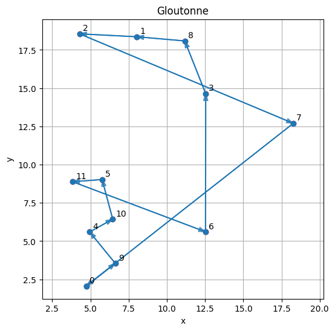

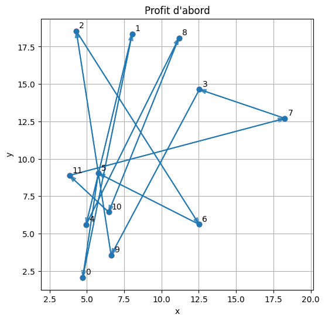

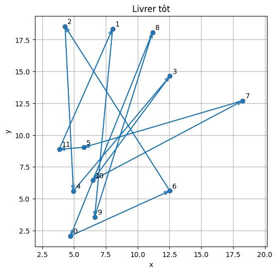

```python
tour_g = greedy_pd(cities_rand, distances_rand, W0_rand, Wmax_rand, a, b)
tour_p = profit_first_pd(cities_rand, distances_rand, W0_rand, Wmax_rand, a, b)
tour_l = deliver_early_pd(cities_rand, distances_rand, W0_rand, Wmax_rand, a, b)

plot_tour(coords_rand, tour_g,  "Gloutonne")
plot_tour(coords_rand, tour_p,  "Profit d'abord")
plot_tour(coords_rand, tour_l,  "Livrer tôt")
```

### Swap

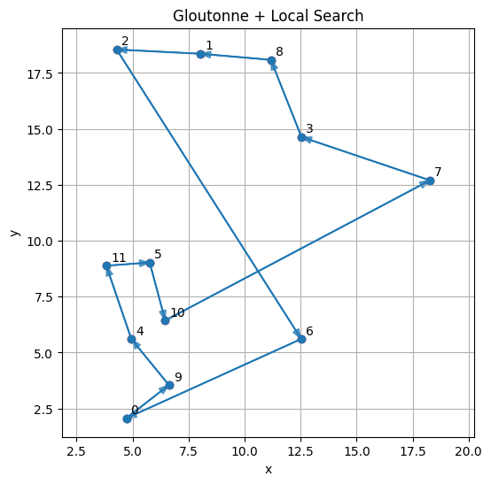

```python
tour_g_ls, _ = local_search_swap(tour_g, cities_rand, distances_rand, W0_rand, Wmax_rand, a, b)
plot_tour(coords_rand, tour_g_ls, "Gloutonne + Local Search")
```

### 2-Opt

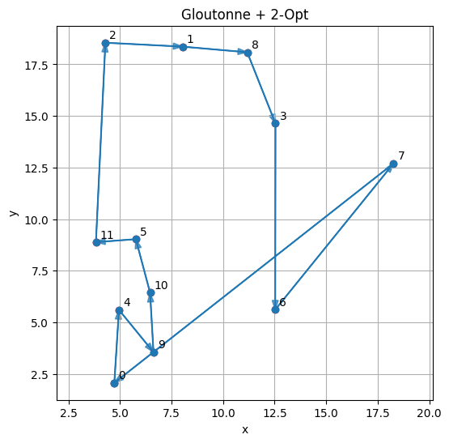

```python
tour_g_2opt = local_search_two_opt(tour_g, cities_rand, distances_rand, W0_rand, Wmax_rand, a, b)
plot_tour(coords_rand, tour_g_2opt, "Gloutonne + 2-Opt")
```

### VND

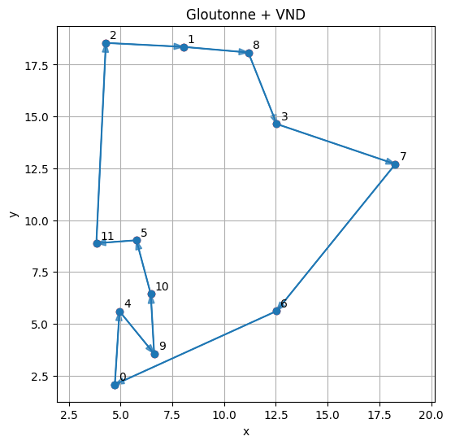

```python
tour_g_vnd = vnd(tour_g, cities_rand, distances_rand, W0_rand, Wmax_rand, a, b)
plot_tour(coords_rand, tour_g_vnd, "Gloutonne + VND")
```

# Influence du paramètre $b$ (avant amélioration locale)

```python
b_values = [0.0, 0.05, 0.1, 0.2, 0.5, 1.0]

results_b_no_ls = []

for b in b_values:

    # tournées heuristiques (sans amélioration)
    tour_g = greedy_pd(cities_rand, distances_rand, W0_rand, Wmax_rand, a, b)
    tour_p = profit_first_pd(cities_rand, distances_rand, W0_rand, Wmax_rand, a, b)
    tour_l = deliver_early_pd(cities_rand, distances_rand, W0_rand, Wmax_rand, a, b)

    # évaluation objective complète
    val_g, _, _, _, _ = evaluate_tour_pd(tour_g, cities_rand, distances_rand, W0_rand, Wmax_rand, a, b)
    val_p, _, _, _, _ = evaluate_tour_pd(tour_p, cities_rand, distances_rand, W0_rand, Wmax_rand, a, b)
    val_l, _, _, _, _ = evaluate_tour_pd(tour_l, cities_rand, distances_rand, W0_rand, Wmax_rand, a, b)

    results_b_no_ls.append((b, val_g, val_p, val_l))
```

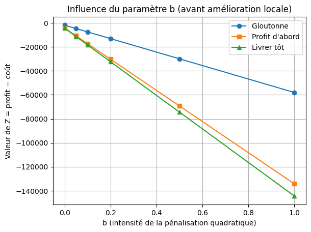

```python
b_list = [r[0] for r in results_b_no_ls]
Z_g = [r[1] for r in results_b_no_ls]
Z_p = [r[2] for r in results_b_no_ls]
Z_l = [r[3] for r in results_b_no_ls]

plt.figure()
plt.plot(b_list, Z_g, marker="o", label="Gloutonne ")
plt.plot(b_list, Z_p, marker="s", label="Profit d'abord")
plt.plot(b_list, Z_l, marker="^", label="Livrer tôt")

plt.xlabel("b (intensité de la pénalisation quadratique)")
plt.ylabel("Valeur de Z = profit − coût")
plt.title("Influence du paramètre b (avant amélioration locale)")
plt.legend()
plt.grid(True)
plt.show()
```

Le graphique ci-dessous représente la valeur objective

$Z = \text{profit} - \text{coût}$

en fonction du paramètre $b$, pour les trois heuristiques **sans** amélioration locale.

On observe des comportements très différents :

## 1. Gloutonne

La courbe décroît moins vite lorsque $b$ augmente.  
Cela s’explique par le fait que la heuristique gloutonne tient déjà compte de la fonction $Z$ pendant la construction de la tournée :  
elle évite de rester trop longtemps avec un camion très chargé.

Ainsi, même lorsque la pénalisation quadratique devient forte, la détérioration reste modérée.

## 2. Profit d’abord

La courbe chute beaucoup plus vite.

Cette heuristique priorise les villes ayant le plus de profit, sans se soucier du poids. Or les objets sont souvent lourds :

- le camion se retrouve rapidement presque plein,
- le terme $bW_i^2$ devient très grand,
- le coût explose dès que $b$ augmente.

On obtient donc un bon profit… mais une valeur de $Z$ catastrophique dès que $b$ n’est plus proche de zéro.

## 3. Livrer tôt

Intuitivement, on pourrait penser que livrer tôt aide — mais dans cette instance, les villes avec beaucoup de livraisons sont parfois éloignées.  
La tournée parcourt donc de longues distances alors que le camion est encore relativement lourd, ce qui génère :

- un coût important au début,
- amplifié brutalement par le terme quadratique.

# Modélisation et résolution PLNE

## Données et paramètres

$N = \{0, ..., n-1\}$ : Ensemble des villes.

$d_{ij}$ : Distance entre la ville $i$ et la ville $j$.

$a$ : Coût par unité de poids et de distance.

$W_{max}$ : Capacité maximale du véhicule.

$W_0$ : Poids initial dans le camion au départ.

$L_i$ : Poids total à livrer à la ville $i$ (constante, on suppose livraison obligatoire).

$R_i$ : Ensemble des objets à ramasser à la ville $i$, avec poids $w_{ik}$ et profit $p_{ik}$.

## Variables de décisions

### Variables de routage :

$$ x_{ij} = \begin{cases} 1 & \text{si le véhicule va directement de $i$ à $j$ } \\ 0 & \text{sinon} \end{cases} $$

### Variables de collecte :

$$ y_{ik} = \begin{cases} 1 & \text{si l'objet $k$ de la ville $i$ est ramassé} \\ 0 & \text{sinon} \end{cases} $$

### Variables de flot :

Quantité de poids transportée par le véhicule sur le trajet de $i$ à $j$ : $$f_{ij} \ge 0$$

### Variables d'ordre :

Variable auxiliaire pour éliminer les sous-tours : $$u_i \in [1, n]$$

## Fonction objective

$$\text{Max } Z = \sum_{i \in N} \sum_{k \in R_i} p_{ik} \cdot y_{ik} - \sum_{i \in N} \sum_{j \in N} a \cdot d_{ij} \cdot f_{ij}$$

On veut maximiser le Profit total moins le Coût total de transport.

Le coût est $C = a \times W_{ij} \times d_{ij}$. Comme $W_{ij}$ dépend de l'ordre de visite, c'est une variable. Multiplier une variable de poids par une variable d'arc binaire $x_{ij}$ rendrait le problème quadratique.

On introduit une variable continue $f_{ij}$ qui représente directement la quantité de charge transportée sur l'arc $(i,j)$. Si l'arc n'est pas utilisé $x_{ij}=0$, alors le flot est nul $f_{ij}=0$. Si l'arc est utilisé $x_{ij}=1$, le flot représente le poids du camion.

## Contraintes

### Structure de la Tournée

Le véhicule doit entrer et sortir exactement une fois de chaque ville.

$$\sum_{j \neq i} x_{ij} = 1 \quad \forall i \in N (Sortant)$$

$$\sum_{i \neq j} x_{ij} = 1 \quad \forall j \in N (Entrant)$$

### Élimination des sous-tours

Empêche le véhicule de faire des petites boucles isolées du dépôt.

$$u_i - u_j + n \cdot x_{ij} \le n - 1 \quad \forall i, j \in N \setminus \{0\}, i \neq j$$

### Couplage Flot - Arc

Le flot ne peut exister que si l'arc est emprunté, et il ne peut dépasser la capacité maximale.

$$0 \le f_{ij} \le W_{max} \cdot x_{ij} \quad \forall i, j \in N$$

### Conservation du Flot

Pour chaque ville $j$ (sauf le dépôt), ce qui sort moins ce qui entre doit être égal à ce qu'on a ajouté (ramassages) moins ce qu'on a enlevé (livraisons). Pour tout $j \in N \setminus \{0\}$ :

$$\underbrace{\sum_{k \neq j} f_{jk}}_{\text{Flux Sortant}} - \underbrace{\sum_{i \neq j} f_{ij}}_{\text{Flux Entrant}} = \underbrace{\sum_{k \in R_j} w_{jk} \cdot y_{jk}}_{\text{Poids Ramassé}} - \underbrace{L_j}_{\text{Poids Livré}}$$

### Initialisation au Dépôt

Le poids qui quitte le dépôt (ville 0) est égal au poids initial + ce qu'on ramasse au dépôt - ce qu'on livre au dépôt.

$$\sum_{j \neq 0} f_{0j} = W_0 + \sum_{k \in R_0} w_{0k} \cdot y_{0k} - L_0$$

## Résolution

```python
def solve_pd_tsp_linear_gurobi(cities, distances, W0, Wmax, a, vehicle_weight=1.0, time_limit=60):
    n = len(cities)

    # Création du modèle
    m = gp.Model("PD-TSP-Linear")
    m.setParam('OutputFlag', 1)
    m.setParam('TimeLimit', time_limit)

    # VARIABLES
    x = {}
    for i in range(n):
        for j in range(n):
            if i != j:
                x[i, j] = m.addVar(vtype=GRB.BINARY, name=f"x_{i}_{j}")

    f = {}
    for i in range(n):
        for j in range(n):
            if i != j:
                f[i, j] = m.addVar(lb=0.0, ub=Wmax, vtype=GRB.CONTINUOUS, name=f"f_{i}_{j}")

    y = {}
    for city in cities:
        for k, _ in enumerate(city.pickups):
            y[city.idx, k] = m.addVar(vtype=GRB.BINARY, name=f"y_{city.idx}_{k}")

    u = {}
    for i in range(1, n):
        u[i] = m.addVar(lb=1, ub=n, vtype=GRB.CONTINUOUS, name=f"u_{i}")

    # OBJECTIF
    total_profit = gp.quicksum(
        city.pickups[k][0] * y[city.idx, k]
        for city in cities
        for k in range(len(city.pickups))
    )

    total_cost = gp.quicksum(
        distances[i][j] * (vehicle_weight * x[i, j] + a * f[i, j])
        for i in range(n)
        for j in range(n)
        if i != j
    )

    m.setObjective(total_profit - total_cost, GRB.MAXIMIZE)

    # CONTRAINTES
    # Structure de la Tournée
    for i in range(n):
        m.addConstr(gp.quicksum(x[i, j] for j in range(n) if j != i) == 1, name=f"out_{i}")
        m.addConstr(gp.quicksum(x[j, i] for j in range(n) if j != i) == 1, name=f"in_{i}")

    # Élimination des sous-tours
    for i in range(1, n):
        for j in range(1, n):
            if i != j:
                m.addConstr(u[i] - u[j] + n * x[i, j] <= n - 1, name=f"mtz_{i}_{j}")

    # Couplage Flot - Arc
    for i in range(n):
        for j in range(n):
            if i != j:
                m.addConstr(f[i, j] <= Wmax * x[i, j], name=f"cap_{i}_{j}")

    # Conservation du Flot
    for j in range(1, n):
        weight_picked = gp.quicksum(cities[j].pickups[k][1] * y[j, k] for k in range(len(cities[j].pickups)))
        weight_delivered = sum(cities[j].deliveries)

        flow_out = gp.quicksum(f[j, k] for k in range(n) if k != j)
        flow_in  = gp.quicksum(f[i, j] for i in range(n) if i != j)

        m.addConstr(flow_out - flow_in == weight_picked - weight_delivered, name=f"flow_bal_{j}")

    # Initialisation au Dépôt
    weight_picked_0 = gp.quicksum(cities[0].pickups[k][1] * y[0, k] for k in range(len(cities[0].pickups)))
    weight_delivered_0 = sum(cities[0].deliveries)
    flow_out_0 = gp.quicksum(f[0, j] for j in range(1, n))
    m.addConstr(flow_out_0 == W0 + weight_picked_0 - weight_delivered_0, name="flow_start")

    # RESOLUTION
    m.optimize()

    # RESULTATS
    if m.status == GRB.OPTIMAL or m.status == GRB.TIME_LIMIT:
        if m.SolCount > 0:

            # Reconstruction de la tournée
            curr = 0
            tour = [0]
            visited_count = 1
            while visited_count < n:
                for j in range(n):
                    if curr != j and x[curr, j].X > 0.5:
                        tour.append(j)
                        curr = j
                        visited_count += 1
                        break

            # On ferme la tournée
            tour_closed = tour + [0]

            # AFFICHAGE DU PLAN
            print("\n" + "="*50)
            print("         DÉTAIL DU PLAN OPTIMAL         ")
            print("="*50)
            print(f"Tournée trouvée : {tour_closed}")

            print("\n[DÉCISIONS DE COLLECTE]")
            for city in cities:
                for k, (profit, weight) in enumerate(city.pickups):
                    if y[city.idx, k].X > 0.5:
                        print(f"  Ville {city.idx}, Objet {k} : RAMASSÉ (Poids: {weight}, Profit: {profit})")
                    else:
                        print(f"  Ville {city.idx}, Objet {k} : LAISSÉ  (Poids: {weight}, Profit: {profit}) -> Trop cher !")

            print("\n[DÉTAIL DU TRANSPORT]")
            current_node = 0
            visited_count = 0
            while visited_count < n:
                next_node = -1
                for j in range(n):
                    if current_node != j and x[current_node, j].X > 0.5:
                        next_node = j
                        break

                if next_node != -1:
                    load = f[current_node, next_node].X
                    dist = distances[current_node][next_node]
                    cout_segment = load * dist * a
                    print(f"  {current_node} -> {next_node} : Charge = {load:5.2f} | Dist = {dist:4.1f} | Coût = {cout_segment:6.2f}")
                    current_node = next_node
                    visited_count += 1
                else:
                    break

            print("-" * 50)
            print(f"PROFIT - COÛT = {m.ObjVal:.2f}")
            print("=" * 50)

            # Retour des données
            y_sol = {}
            for k_idx, var in y.items():
                y_sol[k_idx] = 1 if var.X > 0.5 else 0

            return tour_closed, m.ObjVal, y_sol
        else:
            print("Aucune solution trouvée.")
            return None
    else:
        print("Pas de solution optimale trouvée.")
        return None
```

## Instance de 6 villes

```python
resultat = solve_pd_tsp_linear_gurobi(cities_big, distances_big, W0_big, Wmax_big, a)
```

```
Restricted license - for non-production use only - expires 2026-11-23
Set parameter OutputFlag to value 1
Set parameter TimeLimit to value 60
Gurobi Optimizer version 12.0.3 build v12.0.3rc0 (mac64[x86] - Darwin 23.6.0 23H723)

CPU model: Intel(R) Core(TM) i5-8210Y CPU @ 1.60GHz
Thread count: 2 physical cores, 4 logical processors, using up to 4 threads

Non-default parameters:
TimeLimit  60

Optimize a model with 68 rows, 74 columns and 244 nonzeros
Model fingerprint: 0x8837aca6
Variable types: 35 continuous, 39 integer (39 binary)
Coefficient statistics:
  Matrix range     [1e+00, 4e+01]
  Objective range  [1e+00, 8e+00]
  Bounds range     [1e+00, 4e+01]
  RHS range        [1e+00, 2e+01]
Presolve time: 0.02s
Presolved: 68 rows, 74 columns, 304 nonzeros
Variable types: 35 continuous, 39 integer (39 binary)
Found heuristic solution: objective -864.8000000
Found heuristic solution: objective -771.0000000
Found heuristic solution: objective -755.5000000

Root relaxation: objective -5.961849e+01, 20 iterations, 0.00 seconds (0.00 work units)

    Nodes    |    Current Node    |     Objective Bounds      |     Work
 Expl Unexpl |  Obj  Depth IntInf | Incumbent    BestBd   Gap | It/Node Time

     0     0  -59.61849    0    8 -755.50000  -59.61849  92.1%     -    0s
H    0     0                    -623.4000000  -59.61849  90.4%     -    0s
H    0     0                    -538.9000000  -59.61849  88.9%     -    0s
H    0     0                    -460.7000000  -59.61849  87.1%     -    0s
H    0     0                    -445.3000000  -59.61849  86.6%     -    0s
     0     0  -80.91510    0   16 -445.30000  -80.91510  81.8%     -    0s
H    0     0                    -428.4000000  -80.91510  81.1%     -    0s
H    0     0                    -387.5000000  -80.91510  79.1%     -    0s
H    0     0                    -235.1000000  -80.91510  65.6%     -    0s
```

[output cut: 45 more lines]

```
  Ville 4, Objet 1 : LAISSÉ  (Poids: 6, Profit: 3) -> Trop cher !
  Ville 4, Objet 2 : LAISSÉ  (Poids: 6, Profit: 1) -> Trop cher !
  Ville 5, Objet 0 : LAISSÉ  (Poids: 7, Profit: 2) -> Trop cher !
  Ville 5, Objet 1 : LAISSÉ  (Poids: 10, Profit: 1) -> Trop cher !

[DÉTAIL DU TRANSPORT]
  0 -> 3 : Charge = 24.00 | Dist =  1.0 | Coût =  24.00
  3 -> 4 : Charge = 18.00 | Dist =  2.2 | Coût =  39.60
  4 -> 5 : Charge = 17.00 | Dist =  2.2 | Coût =  37.40
  5 -> 1 : Charge = 11.00 | Dist =  4.5 | Coût =  49.50
  1 -> 2 : Charge =  6.00 | Dist =  7.1 | Coût =  42.60
  2 -> 0 : Charge =  4.00 | Dist =  5.0 | Coût =  20.00
--------------------------------------------------
PROFIT - COÛT = -235.10
==================================================
```

#### Résultats

| Heuristique | Tournée | Profit | Coût linéaire | Objectif linéaire |
| --- | --- | --- | --- | --- |
| Gloutonne | [0, 3, 4, 5, 1, 2] | 8 | 566.90 | -558.90 |
| Profit d'abord | [0, 4, 3, 5, 1, 2] | 7 | 696.50 | -689.50 |
| Livrer tôt | [0, 3, 5, 1, 2, 4] | 8 | 637.50 | -629.50 |
| Gurobi | [0, 3, 4, 5, 1, 2] | 0 | 235.10 | -235.10 |

#### Interprétation

Toutes les heuristiques (Gloutonne, Profit d'abord, Livrer tôt) ont cherché à ramasser des objets. Cependant, le modèle exact a déterminé que la stratégie optimale était de ne rien ramasser du tout. En effet, le gain marginal apporté par les objets est petit par rapport au surcoût de transport engendré par leur poids sur la distance restante. Les heuristiques, en voulant "rentabiliser" le passage par les villes, ont fini par alourdir inutilement le véhicule, faisant exploser le coût.

On remarque que la tournée géométrique trouvée par Gurobi [0, 3, 4, 5, 1, 2] est identique à celle trouvée par l'heuristique Gloutonne. Cela signifie que l'heuristique Gloutonne avait trouvé le bon chemin, mais elle a échoué sur le plan de chargement.

L'apport du PLNE ici n'a pas été de trouver un raccourci géographique, mais de réaliser un arbitrage économique fin : sacrifier tout le profit pour minimiser drastiquement les coûts.

## Visualisation

```python
def visualize_pd_tsp(tour, cities, coords, y_sol, title="Visualisation PD-TSP"):
    plt.figure(figsize=(10, 8))

    # Tracer les Villes
    for i, (x, y) in enumerate(coords):
        color = 'red' if i == 0 else 'skyblue'
        size = 300 if i == 0 else 200
        plt.scatter(x, y, c=color, s=size, edgecolors='k', zorder=2)
        plt.text(x, y, str(i), fontsize=12, ha='center', va='center', fontweight='bold', zorder=3)

        city = cities[i]

        # Poids livré
        delivered = sum(city.deliveries)

        # Poids ramassé
        picked = 0
        for k, (_, w) in enumerate(city.pickups):
            # On vérifie si y_sol contient la décision positive pour cet objet
            if y_sol.get((i, k), 0) == 1:
                picked += w

        # Construction du label
        label_parts = []
        if delivered > 0:
            label_parts.append(f"Liv: -{delivered}")
        if picked > 0:
            label_parts.append(f"Ram: +{picked}")

        if label_parts:
            info_text = "\n".join(label_parts)
            plt.text(x + 0.5, y + 0.5, info_text, fontsize=9,
                     bbox=dict(facecolor='white', alpha=0.7, edgecolor='gray', boxstyle='round'))

    # Tracer la Tournée
    for k in range(len(tour) - 1):
        i = tour[k]
        j = tour[k+1]

        xi, yi = coords[i]
        xj, yj = coords[j]

        plt.arrow(xi, yi, xj - xi, yj - yi,
                  head_width=0.3, head_length=0.5, fc='k', ec='k',
                  length_includes_head=True, alpha=0.6, zorder=1)

    plt.title(title, fontsize=15)
    plt.xlabel("X")
    plt.ylabel("Y")
    plt.grid(True, linestyle='--', alpha=0.5)
    plt.axis('equal')
    plt.tight_layout()
    plt.show()
```

```python
def get_weight_profile(tour, cities, W0, y_sol):
    weights = []
    current_W = W0

    for node_idx in tour:
        city = cities[node_idx]

        # Livraisons
        w_delivered = sum(city.deliveries)
        current_W -= w_delivered

        # Ramassages
        w_picked = 0
        for k, (_, w) in enumerate(city.pickups):
            if y_sol.get((city.idx, k), 0) == 1:
                w_picked += w

        current_W += w_picked
        weights.append(current_W)

    return weights

def plot_weight_evolution(tour, weights, Wmax):
    plt.figure(figsize=(10, 6))

    # Création de l'axe X
    steps = range(len(tour))

    # Tracé de la courbe de poids
    plt.plot(steps, weights, marker='o', linestyle='-', drawstyle='steps-post', label='Poids camion', linewidth=2, color='blue')

    # Ligne de capacité Max
    plt.axhline(y=Wmax, color='r', linestyle='--', linewidth=2, label=f'Capacité Max ($W_{{max}}={Wmax}$)')

    # Esthétique
    plt.title("Évolution du poids transporté au fil de la tournée (Solution Gurobi)", fontsize=14)
    plt.xlabel("Étapes (Villes visitées)", fontsize=12)
    plt.ylabel("Poids Total", fontsize=12)
    plt.xticks(steps, [f"Ville {i}" for i in tour])
    plt.grid(True, linestyle=':', alpha=0.6)
    plt.legend()
    plt.ylim(bottom=0, top=max(Wmax + 5, max(weights) + 2)) # Un peu de marge au dessus

    # Affichage
    for i, w in enumerate(weights):
        plt.text(i, w + 0.5, f"{w:.1f}", ha='center', va='bottom', fontweight='bold')

    plt.show()
```

## Insance aléatoire (12 villes)

```
Set parameter OutputFlag to value 1
Set parameter TimeLimit to value 30
Gurobi Optimizer version 12.0.3 build v12.0.3rc0 (mac64[x86] - Darwin 23.6.0 23H723)

CPU model: Intel(R) Core(TM) i5-8210Y CPU @ 1.60GHz
Thread count: 2 physical cores, 4 logical processors, using up to 4 threads

Non-default parameters:
TimeLimit  30

Optimize a model with 278 rows, 300 columns and 1136 nonzeros
Model fingerprint: 0x2bfa8680
Variable types: 143 continuous, 157 integer (157 binary)
Coefficient statistics:
  Matrix range     [1e+00, 4e+01]
  Objective range  [1e+00, 2e+01]
  Bounds range     [1e+00, 4e+01]
  RHS range        [1e+00, 2e+01]
Presolve time: 0.02s
Presolved: 278 rows, 300 columns, 2126 nonzeros
Variable types: 143 continuous, 157 integer (157 binary)
Found heuristic solution: objective -2761.704130
Found heuristic solution: objective -2123.660498

Root relaxation: objective -1.153302e+02, 50 iterations, 0.00 seconds (0.00 work units)

    Nodes    |    Current Node    |     Objective Bounds      |     Work
 Expl Unexpl |  Obj  Depth IntInf | Incumbent    BestBd   Gap | It/Node Time

     0     0 -115.33023    0   28 -2123.6605 -115.33023  94.6%     -    0s
H    0     0                    -563.3733615 -115.33023  79.5%     -    0s
     0     0 -210.31948    0   35 -563.37336 -210.31948  62.7%     -    0s
     0     0 -215.17651    0   39 -563.37336 -215.17651  61.8%     -    0s
     0     0 -223.58678    0   38 -563.37336 -223.58678  60.3%     -    0s
H    0     0                    -535.1572194 -224.15364  58.1%     -    0s
     0     0 -224.15364    0   40 -535.15722 -224.15364  58.1%     -    0s
     0     0 -243.61525    0   43 -535.15722 -243.61525  54.5%     -    0s
H    0     0                    -479.2064745 -243.96710  49.1%     -    0s
     0     0 -243.96710    0   44 -479.20647 -243.96710  49.1%     -    0s
     0     0 -243.96710    0   45 -479.20647 -243.96710  49.1%     -    0s
```

[output cut: 80 more lines]

```
  0 -> 4 : Charge = 19.00 | Dist =  3.5 | Coût =  67.33
  4 -> 10 : Charge = 12.00 | Dist =  1.7 | Coût =  20.70
  10 -> 5 : Charge =  6.00 | Dist =  2.7 | Coût =  16.11
  5 -> 11 : Charge =  3.00 | Dist =  1.9 | Coût =   5.82
  11 -> 6 : Charge =  0.00 | Dist =  9.3 | Coût =   0.00
  6 -> 7 : Charge =  7.00 | Dist =  9.1 | Coût =  63.88
  7 -> 3 : Charge =  2.00 | Dist =  6.0 | Coût =  12.10
  3 -> 8 : Charge = 11.00 | Dist =  3.7 | Coût =  40.81
  8 -> 1 : Charge = 10.00 | Dist =  3.2 | Coût =  31.51
  1 -> 2 : Charge =  8.00 | Dist =  3.7 | Coût =  29.99
  2 -> 9 : Charge =  0.00 | Dist = 15.2 | Coût =   0.00
  9 -> 0 : Charge =  8.00 | Dist =  2.4 | Coût =  19.31
--------------------------------------------------
PROFIT - COÛT = -364.12
==================================================
```

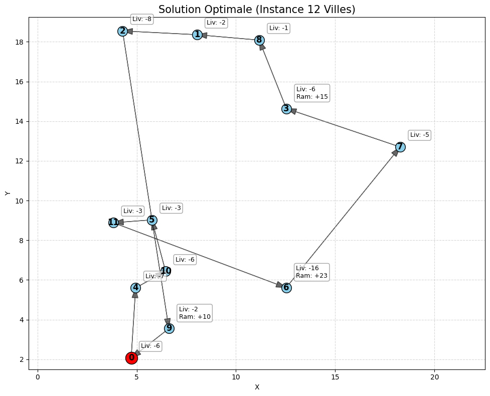

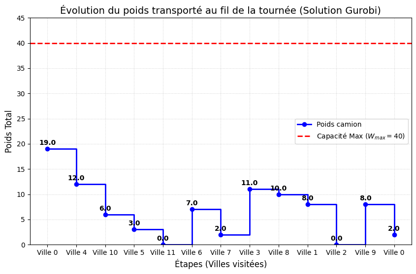

```python
res_rand = solve_pd_tsp_linear_gurobi(cities_rand, distances_rand, W0_rand, Wmax_rand, a, time_limit=30)

if res_rand:
    tour_rand, val_rand, y_rand = res_rand

    visualize_pd_tsp(tour_rand, cities_rand, coords_rand, y_rand, title="Solution Optimale (Instance 12 Villes)")
    poids_rand = get_weight_profile(tour_rand, cities_rand, W0_rand, y_rand)
    plot_weight_evolution(tour_rand, poids_rand, Wmax_rand)
```

### Résultats et interprétation

Le solveur a trouvé l'optimum global avec une valeur objective de -364.12. Le modèle a choisi de ne ramasser que 3 objets, générant un profit minime. La majorité de la valeur objective négative provient des coûts de déplacement du poids initial $W_0$ et des livraisons obligatoires.

Contrairement à une intuition naïve, Gurobi a rejeté la grande majorité des objets. Regardons la Ville 1, elle proposait 3 objets avec des profits de 5, 3 et 1. Ils ont tous été laissés. La ville 1 est visitée vers la fin. Mais même à ce stade, ajouter du poids obligerait à transporter cette charge jusqu'à la ville 2, puis la 9, puis le dépôt. Le coût marginal dépasse le gain fixe du profit. L'objet 1 de la Ville 9 a été ramassé. La ville 9 est l'avant-dernière étape avant le retour au dépôt. Transporter cet objet ne coûte cher que sur une très courte distance. C'est rentable.

La courbe bleue descend en escalier. Le véhicule commence lourd et cherche à se délester. Il visite les villes 4, 10, 5 au début, ce qui correspond à des lieux de livraison importants ou proches. Les "Trajets à Vide", entre la ville 11 et la ville 6 et entre la ville 2 et la ville 9 où la charge est nulle. Gurobi a optimisé la route pour créer des segments où le camion roule totalement à vide. C'est une optimisation que l'heuristique "Gloutonne" rate souvent car elle cherche toujours à livrer ou ramasser à chaque étape, alors que parfois, il faut juste rouler pour se repositionner sans charge.

La tournée semble faire des zigzags qui ne sont pas optimaux géométriquement à cause des croisements possibles. Si c'était un TSP classique ou il faut minimiser la distance, la boucle serait plus "ronde". Ici, le modèle accepte de faire un détour si cela permet de visiter une ville de livraison plus tôt et donc réduire le poids $W_i$. C'est la preuve mathématique que dans le PD-TSP linéaire, l'ordre de visite est important.

Cette instance démontre la supériorité de l'approche exacte sur les petites instances : elle ne se contente pas de trouver un chemin court, elle réalise un arbitrage financier complexe sur chaque objet. Elle prouve que pour maximiser $Z$, il faut souvent savoir renoncer au profit immédiat pour sauver du coût de transport, une subtilité que l'heuristique "Profit d'abord" a totalement manquée avec son coût explosif.

# Comparaisons

## Lectures fichiers

Nous avons écrit une fonction pour récupérer les données à partir des fichiers .tsp obtenu depuis le site développé par H. Hernández-Pérez.

```python
def read_tsp_instance(filename, profit_per_weight=1000):
    with open(filename, 'r') as f:
        content = f.read()

    lines = content.strip().split('\n')
    data = {}

    coords = {}
    demands = {}
    section = None

    for line in lines:
        line = line.strip()
        if not line or line == "EOF":
            continue

        # Lecture en-têtes
        if ":" in line and section is None:
            parts = line.split(":", 1)
            data[parts[0].strip()] = parts[1].strip()
            continue

        # Sections
        if line == "NODE_COORD_SECTION":
            section = "COORD"
            continue
        if line == "DEMAND_SECTION":
            section = "DEMAND"
            continue
        if line.startswith("DISPLAY_DATA"):
            section = "IGNORE"
            continue

        # Parsing
        parts = line.split()
        if section == "COORD":
            node_id = int(parts[0])
            coords[node_id] = (float(parts[1]), float(parts[2]))
        elif section == "DEMAND":
            node_id = int(parts[0])
            demands[node_id] = float(parts[1])

    dim_file = int(data.get("DIMENSION", 0))

    if coords[1] == coords[dim_file]:
        n_cities = dim_file - 1
    else:
        n_cities = dim_file

    # Lecture capacité et W0 initial
    Wmax = float(data.get("CAPACITY"))
    W0 = demands.get(1, 0)
    if W0 < 0: W0 = 0

    cities = []
    coords_list = []

    # Création des villes
    for i in range(n_cities):
        file_id = i + 1
        d_val = demands.get(file_id, 0)

        deliveries = []
        pickups = []

        if file_id == 1:
            # Dépôt
            cities.append(City(i, [], []))
        else:
            if d_val < 0:
                deliveries.append(abs(d_val))
            elif d_val > 0:
                pickups.append((d_val * profit_per_weight, d_val))

            cities.append(City(i, deliveries, pickups))

        coords_list.append(coords[file_id])

    distances = [[0.0] * n_cities for _ in range(n_cities)]
    for i in range(n_cities):
        for j in range(n_cities):
            distances[i][j] = math.dist(coords_list[i], coords_list[j])

    # Calcul du poids total à livrer
    total_deliveries_needed = sum(sum(c.deliveries) for c in cities)

    # Ajustement de W0
    if W0 < total_deliveries_needed:
        W0 = total_deliveries_needed

    # Ajustement de Wmax (Le camion doit pouvoir contenir W0)
    if Wmax < W0:
        Wmax = W0

    return cities, distances, coords_list, W0, Wmax
```

## Benchmark

Nous avons également écrit des fonctions pour pouvoir lancer nos heuristiques sur plusieurs instances du problèmes et en déduire des statistiques.

### Quadratique

```python
def run_ls_swap(cities, dists, W0, Wmax, a, b):
    # Solution initiale (Gloutonne)
    tour_init = greedy_pd(cities, dists, W0, Wmax, a, b)
    # Amélioration Swap
    tour_final, _ = local_search_swap(tour_init, cities, dists, W0, Wmax, a, b)
    return tour_final

def run_ls_2opt(cities, dists, W0, Wmax, a, b):
    # Solution initiale (Gloutonne)
    tour_init = greedy_pd(cities, dists, W0, Wmax, a, b)
    # Amélioration 2-Opt
    tour_final, _ = local_search_two_opt(tour_init, cities, dists, W0, Wmax, a, b)
    return tour_final

def run_vnd(cities, dists, W0, Wmax, a, b):
    # Solution initiale (Gloutonne)
    tour_init = greedy_pd(cities, dists, W0, Wmax, a, b)
    # Amélioration VND
    tour_final, _ = vnd(tour_init, cities, dists, W0, Wmax, a, b)
    return tour_final
```

```python
def run_benchmark_complete(folder_path, a=1.0, b=0.1, profit_factor=5000.0):

    heuristics = [
        # --- Méthodes Constructives ---
        ("Gloutonne", greedy_pd),
        ("Profit d'abord", profit_first_pd),
        ("Livrer tôt", deliver_early_pd),

        # --- Méthodes Itératives (base Gloutonne) ---
        ("Gloutonne + Swap", run_ls_swap),
        ("Gloutonne + 2-Opt", run_ls_2opt),
        ("Gloutonne + VND", run_vnd)
    ]

    # Récupération des fichiers
    search_path = os.path.join(folder_path, "*.tsp")
    files = glob.glob(search_path)

    if not files:
        print(f"Aucun fichier trouvé dans {folder_path}")
        return None

    print(f"Lancement du benchmark complet sur {len(files)} instances...")
    print(f"Paramètres : b={b} (Quadratique), Profit Factor={profit_factor}")
    print("-" * 60)

    results = []

    for filepath in files:
        filename = os.path.basename(filepath)

        # Lecture
        try:
            cities, dists, _, W0, Wmax = read_tsp_instance(filepath, profit_factor)
        except Exception as e:
            print(f"Skipping {filename}: {e}")
            continue

        # Boucle sur les méthodes
        for name, func in heuristics:
            start_t = time.perf_counter()

            # Exécution
            tour = func(cities, dists, W0, Wmax, a, b)

            end_t = time.perf_counter()
            duration = end_t - start_t

            # Évaluation
            val, prof, cost, _, _ = evaluate_tour_pd(tour, cities, dists, W0, Wmax, a, b)

            results.append({
                "Instance": filename,
                "Méthode": name,
                "Temps (s)": duration,
                "Objectif (Z)": val,
                "Profit": prof,
                "Coût": cost
            })

    return pd.DataFrame(results)
```

### Linéaire

```python
def run_linear_gurobi_wrapper(cities, dists, W0, Wmax, a, b=0):
    res = solve_pd_tsp_linear_gurobi(cities, dists, W0, Wmax, a, time_limit=120)
    if res:
        tour, val, _ = res
        return tour, val
    return None, None

def run_benchmark_linear_compare(folder_path, a=1.0, profit_factor=5000.0):
    b = 0.0

    # Liste des méthodes à comparer
    competitors = [
        # Heuristiques simples
        ("Gloutonne", greedy_pd),
        ("Profit d'abord", profit_first_pd),
        ("Livrer tôt", deliver_early_pd),

        # Méthodes Itératives (Amélioration de la Gloutonne)
        ("Gloutonne + Swap", lambda c, d, w0, wm, a, b: local_search_swap(greedy_pd(c, d, w0, wm, a, b), c, d, w0, wm, a, b)[0]),
        ("Gloutonne + 2-Opt", lambda c, d, w0, wm, a, b: local_search_two_opt(greedy_pd(c, d, w0, wm, a, b), c, d, w0, wm, a, b)[0]),
        ("Gloutonne + VND",   lambda c, d, w0, wm, a, b: vnd(greedy_pd(c, d, w0, wm, a, b), c, d, w0, wm, a, b)[0]),
    ]

    # Fichiers
    search_path = os.path.join(folder_path, "*.tsp")
    files = glob.glob(search_path)

    if not files:
        print(f"Aucun fichier trouvé dans {folder_path}")
        return None

    print(f"Lancement du Benchmark LINÉAIRE (b=0) avec GUROBI sur {len(files)} instances...")
    print("-" * 80)

    results = []

    for filepath in files:
        filename = os.path.basename(filepath)
        print(f"Traitement de {filename}...", end=" ")

        try:
            cities, dists, _, W0, Wmax = read_tsp_instance(filepath, profit_factor)
        except Exception as e:
            print(f"Erreur lecture: {e}")
            continue

        # Lancer les Heuristiques & Itératives
        for name, func in competitors:
            start_t = time.perf_counter()
            tour = func(cities, dists, W0, Wmax, a, b)
            end_t = time.perf_counter()

            val, prof, cost, _, _ = evaluate_tour_pd(tour, cities, dists, W0, Wmax, a, b)

            results.append({
                "Instance": filename,
                "Type": "Heuristique",
                "Méthode": name,
                "Temps (s)": end_t - start_t,
                "Objectif": val,
                "Profit": prof,
                "Coût": cost,
                "Gap (%)": None
            })

        # Lancer Gurobi
        print("Gurobi...", end=" ")
        start_g = time.perf_counter()
        tour_opt, val_opt = run_linear_gurobi_wrapper(cities, dists, W0, Wmax, a)
        end_g = time.perf_counter()

        if tour_opt is not None:
            _, prof_opt, cost_opt, _, _ = evaluate_tour_pd(tour_opt, cities, dists, W0, Wmax, a, b)

            results.append({
                "Instance": filename,
                "Type": "Exact",
                "Méthode": "Gurobi (Optimal)",
                "Temps (s)": end_g - start_g,
                "Objectif": val_opt,
                "Profit": prof_opt,
                "Coût": cost_opt,
                "Gap (%)": 0.0
            })

            # Calcul du GAP pour les heuristiques sur cette instance
            # Gap = (Obj_Opt - Obj_Heur) / Obj_Opt
            for res in results:
                if res["Instance"] == filename and res["Méthode"] != "Gurobi (Optimal)":
                    res["Gap (%)"] = abs(val_opt - res["Objectif"])

        else:
            print("(Pas de solution Gurobi)", end=" ")

        print("OK.")

    return pd.DataFrame(results)
```

## Résultats sur 20 fichiers

### Heuristiques et méthodes itérative

Ici, nous lançons notre fonction sur 20 fichiers. Nous avons utilisé le coût quadratique dans cette partie.

```python
folder_target = "./TS2004t2"
df_complete = run_benchmark_complete(folder_target, a=1.0, b=0.1, profit_factor=5000.0)

if df_complete is not None and not df_complete.empty:
    print("\n" + "="*60)
    print("CLASSEMENT MOYEN DES MÉTHODES")
    print("="*60)

    summary = df_complete.groupby("Méthode")[["Temps (s)", "Objectif (Z)", "Profit", "Coût"]].mean()
    summary = summary.sort_values(by="Objectif (Z)", ascending=False)

    print(summary)
```

```
Lancement du benchmark complet sur 20 instances...
Paramètres : b=0.1 (Quadratique), Profit Factor=5000.0
------------------------------------------------------------

============================================================
CLASSEMENT MOYEN DES MÉTHODES
============================================================
                   Temps (s)  Objectif (Z)    Profit          Coût
Méthode
Gloutonne + VND     0.291160 -1.614763e+05  206750.0  3.682263e+05
Gloutonne + Swap    0.050757 -3.507028e+05  172250.0  5.229528e+05
Gloutonne + 2-Opt   0.108803 -3.912934e+05  168250.0  5.595434e+05
Livrer tôt          0.000066 -5.562050e+05  222750.0  7.789550e+05
Gloutonne           0.007493 -7.531107e+05  144000.0  8.971107e+05
Profit d'abord      0.000122 -2.017514e+06    6250.0  2.023764e+06
```

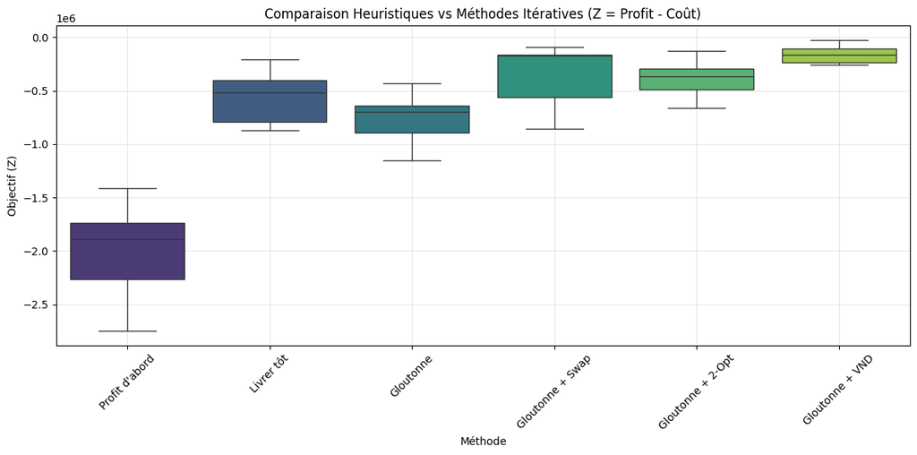

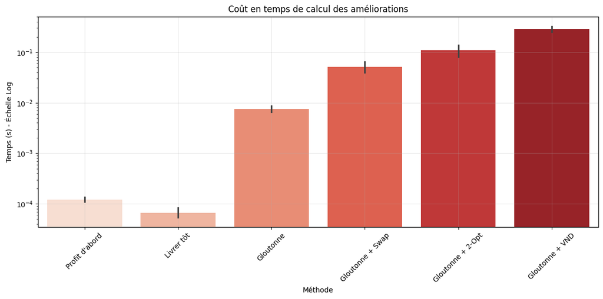

```python
if df_complete is not None:
    plt.figure(figsize=(12, 6))

    order = ["Profit d'abord", "Livrer tôt", "Gloutonne",
             "Gloutonne + Swap", "Gloutonne + 2-Opt", "Gloutonne + VND"]

    sns.boxplot(data=df_complete, x="Méthode", y="Objectif (Z)", order=order, palette="viridis")

    plt.title("Comparaison Heuristiques vs Méthodes Itératives (Z = Profit - Coût)")
    plt.xticks(rotation=45)
    plt.grid(True, alpha=0.3)
    plt.tight_layout()
    plt.show()

    # Le Temps de calcul
    plt.figure(figsize=(12, 6))
    sns.barplot(data=df_complete, x="Méthode", y="Temps (s)", order=order, palette="Reds")
    plt.title("Coût en temps de calcul des améliorations")
    plt.xticks(rotation=45)
    plt.yscale("log")
    plt.ylabel("Temps (s) - Échelle Log")
    plt.grid(True, alpha=0.3)
    plt.tight_layout()
    plt.show()
```

#### Résultats et interprétation

Le tableau de résultats et le graphique révèlent une hiérarchie claire :

- **Le Vainqueur (Gloutonne + VND)** : Cette méthode domine largement le classement. C'est la seule approche qui parvient à maintenir un profit élevé tout en contenant l'explosion des coûts quadratiques. Le VND réussit là où les autres échouent car il optimise sur deux fronts simultanément : la géométrie via 2-Opt et la gestion de charge via Swap.
- **L'importance de l'échange (Swap vs 2-Opt)** : On remarque que Gloutonne + Swap performe mieux que Gloutonne + 2-Opt. Dans la variante quadratique, l'ordre de visite qui détermine l'accumulation du poids $W_i$ est plus critique que la distance pure. L'opérateur Swap permet de déplacer une ville de collecte tardive vers le début (ou inversement) pour lisser la courbe de charge, ce que le 2-Opt qui inverse des segments fait moins efficacement.

Les résultats bruts des heuristiques simples mettent en lumière les pièges du PD-TSP quadratique :

- **Profit d'abord** :Cette stratégie obtient le pire score. Plus surprenant encore, elle génère le profit le plus faible. L'heuristique construit une tournée incohérente géographiquement en sautant d'un gros profit à l'autre. Lors de l'évaluation, l'algorithme intelligent de chargement se rend compte que transporter ces objets sur de telles distances coûterait une fortune en pénalités quadratiques. Il décide donc de ne rien ramasser pour limiter la casse. C'est l'exemple parfait d'une tournée mal structurée qui rend toute collecte non rentable.
- **Livrer tôt**: Cette méthode génère le plus gros profit moyen, supérieur même au VND, mais finit avec un score médiocre. En livrant tôt, le camion se vide vite, ce qui libère de la capacité. L'algorithme de chargement en profite pour tout ramasser. Cependant, pour livrer tôt, le camion fait de longs détours. Le coût de transport sur ces longues distances finit par dépasser les gains du profit supplémentaire.

Les heuristiques constructives seules ne suffisent pas : elles tombent soit dans le piège du coût (Livrer tôt) soit dans celui de la non-faisabilité économique (Profit d'abord). La gestion du poids prévaut sur la gestion de la distance : Swap bat 2-Opt. L'approche Gloutonne + VND est la seule viable, offrant le meilleur compromis entre maximisation du profit et minimisation de la surcharge.

### Gurobi et Heuristiques et méthodes itérative

```python
#df_linear = run_benchmark_linear_compare("./TS2004t2", a=1.0, profit_factor=5000.0)

if df_linear is not None and not df_linear.empty:

    # Tableau récapitulatif moyen
    print("\n" + "="*60)
    print("RÉSULTATS MOYENS (LINÉAIRE b=0)")
    print("="*60)
    summary = df_linear.groupby("Méthode")[["Temps (s)", "Objectif", "Profit", "Coût", "Gap (%)"]].mean()
    summary = summary.sort_values(by="Objectif", ascending=False)
    print(summary)

    # Performance relative (Objectif)
    plt.figure(figsize=(14, 7))
    sns.boxplot(data=df_linear, x="Méthode", y="Objectif", hue="Type", dodge=False, palette="Set2")
    plt.title("Comparaison des valeurs de l'Objectif (Z) - Cas Linéaire")
    plt.xticks(rotation=45)
    plt.grid(True, alpha=0.3)
    plt.tight_layout()
    plt.show()

    # Ecart à l'optimale (Gap)
    df_heur = df_linear[df_linear["Type"] == "Heuristique"]

    plt.figure(figsize=(14, 7))
    sns.barplot(data=df_heur, x="Méthode", y="Gap (%)", estimator="mean", errorbar=None, palette="Reds")
    plt.title("Écart moyen par rapport à la solution Gurobi (Gap Absolu)")
    plt.ylabel("Écart moyen (Delta Z)")
    plt.xticks(rotation=45)
    plt.grid(True, axis='y', alpha=0.3)
    plt.tight_layout()
    plt.show()
```

#### Résultats et interprétation

[figure not shown]

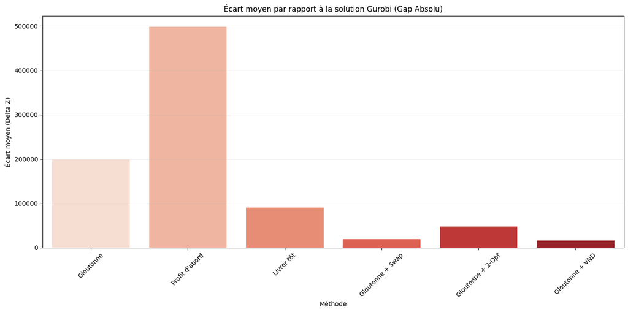

**La limite des méthodes exactes** :

- Cela ne signifie pas que l'heuristique a trouvé une solution meilleure que l'optimale. Cela indique que pour des instances de 20 villes, le problème devient trop complexe pour être résolu exactement en 120 secondes.
- Gurobi n'a souvent pas eu le temps de converger et a renvoyé la meilleure solution faisable trouvée avant l'arrêt. L'heuristique VND, beaucoup plus rapide, a eu le temps d'explorer l'espace de recherche plus efficacement que Gurobi ne l'a fait.

**Hiérarchie des performances** :

Le graphique illustre la distribution des solutions :

- Gloutonne + VND : C'est la méthode la plus robuste. Elle maximise le profit tout en gardant le coût de transport au plus bas.
- Gurobi : Bien qu'il soit un solveur exact, il est pénalisé par le temps. Il trouve des profits similaires mais n'a pas eu le temps d'optimiser le routage aussi finement que le VND pour réduire les coûts.
- Gloutonne + Swap : Très proche du VND, ce qui confirme encore une fois que l'échange de sommets (Swap) est l'opérateur clé pour ce problème.
- Heuristiques simples : Les méthodes constructives seules (Gloutonne, Profit d'abord) produisent des résultats négatifs ou très faibles. L'écart immense visualisé dans le graphique des Gaps montre qu'elles sont inutilisables sans amélioration locale.

**Analyse Profit vs Coût** :

- Profit moyen : $6 250$ (extrêmement faible).
- Coût moyen : $394 860$ (énorme). L'heuristique propose une tournée tellement incohérente géographiquement que le coût de transport pour n'importe quel objet devient exorbitant. L'algorithme d'évaluation décide donc rationnellement de ne rien charger dans le camion, mais le camion doit quand même parcourir la longue distance à vide, d'où le déficit.

Ce test valide l'approche heuristique pour les instances de taille moyenne à grande. Alors que Gurobi garantit l'optimalité sur de petites instances, il s'essouffle exponentiellement vite. Pour des applications industrielles réalistes du PD-TSP, l'approche Gloutonne + VND est supérieure, fournissant de meilleures solutions en une fraction du temps.

# Conclusion

Ce projet nous a permis d'explorer la complexité du PD-TSP, un problème où l'optimisation ne se limite pas à trouver le chemin le plus court, mais consiste à gérer intelligemment un stock dynamique à bord d'un véhicule.

À l'issue de nos travaux de modélisation (linéaire et quadratique), d'implémentation d'heuristiques et de comparaison avec un solveur exact, trois conclusions majeures émergent :

- **Le poids dicte la stratégie** : L'introduction d'un coût dépendant du poids change radicalement la nature du problème par rapport au TSP classique. Nos expériences montrent que les stratégies naïves comme "Profit d'abord" échouent car elles ignorent le coût exorbitant du transport de charges lourdes sur de longues distances. Dans la variante quadratique, minimiser la surcharge devient prioritaire sur la maximisation du profit brut.
- **Supériorité de l'approche hybride (Gloutonne + VND)** : L'approche la plus performante n'est pas la plus complexe mathématiquement, mais celle qui combine une construction raisonnée (heuristique gloutonne) avec une recherche locale agressive. Le VND s'est révélé indispensable : l'opérateur Swap optimise la gestion de la charge, tandis que le 2-Opt optimise la géométrie.
- **Limites de la résolution exacte** : Sur les petites instances, il a prouvé que la solution optimale consiste parfois à renoncer à certains profits pour sauver des coûts de transport, une subtilité que les heuristiques peinent à saisir. Sur les instances plus grandes, le solveur exact s'essouffle face à l'explosion combinatoire. Dans notre benchmark, l'heuristique VND a surpassé Gurobi en moyenne avec une limite de temps, confirmant que pour des applications logistiques réelles et dynamiques, les métaheuristiques restent l'outil de choix.

En définitive, résoudre le PD-TSP revient à trouver un équilibre constant entre gagner (ramasser des objets) et ne pas dépenser (limiter le poids et la distance).